# Ethics and Practice in Data Science Final Project

International Commuters

#Overview & Goals

This markdown file will be the place where we can conduct our exploratory data analysis.

Below you will find the questions that we are using to explore the data and who is responsible for conducting the data analysis associated with that question.

By the end of this process we will have as a team:

1. Imported the cleaned dataset from Lab 3
2. All of the EDA questions examined with clear code & written explanations of the results.
3. Data visualization for the various EDAs.
   - One question to resolve is - is Lilly creating all the viz or should this be the responsibility the people assigned the questions.
   - Either way we need one coherent theme across all viz to be imported into the presentation
4. A coherent final presentation (in a separate powerpoint created by Lilly), along with a clear assignment of who is presenting what.

LINK TO SLIDES: https://docs.google.com/presentation/d/1Z7EedURd1mhE6WoUVpifnr4v6w-2GmTj2a6IKPiLOHg/edit?usp=sharing

*General notes: >Some example code for cleaning and data analysis will be pulled into the presentation, so make sure you are annotating code as you go so we can explain what each line does if needed.

> keep committing your progress with clear messages so we can see contributions and troubleshoot errors if needed.

#Task Assignment

### 0.0.1 **1. Traffic & Volume Patterns**

> Lilly is going to be working on this question
- **How does bidding volume change across hours of the day and days of the week?**
- **When are the peak bidding periods, and what might explain those spikes?**

### 0.0.2 **2. Bid Behavior & Competitiveness**

> Edwin is going to be working on this question
- **How do bid amounts differ between winning and losing bids?**
- **Is there a relationship between bid amount and the probability of winning an auction?**
- **Do certain advertisers consistently place higher or lower bids compared to others?**

### 0.0.3 **3. Auction Outcomes**

> Bingtang is going to be working on this question
- **Which features (e.g., bid amount, time of day, advertiser) are most predictive of a win?**
- **Are there systematic differences in outcomes across devices, regions, or ad categories?**

### 0.0.4 **4. Data Quality–Driven Questions**

> Neal is going to be working on this question
- **How do missing or inconsistent fields (e.g., timestamps, IDs, bid amounts) influence auction outcomes or patterns?**
- **How does the cleaned dataset change our interpretation of key trends compared to the raw data?**

#Setup

##Packages

```r
library(tidyverse)
library(arrow)
library(logger)
library(glue)
library(dplyr)
library(tidyr)
library(rlang)
library(lubridate)
library(tictoc)
library(here)
library(jsonlite)
library(scales)
library(knitr)
library(kableExtra)
library(DT)
library(tigris)   # for zctas()
library(sf)       # for spatial functions
library(stringr)  # for string cleaning
# source(here("src", "data_cleaning.r"))
library(zipcodeR)
library(arrow)
library(ggridges)   # ridge plots
library(tigris)     # US geographic boundaries
library(sf)         # spatial data handling
library(viridis)    # colorblind-safe palettes(maps)
library(mgcv)       # GAM/BAM modeling
library(pROC)

source(here("src", "data_cleaning.r"))  # Functions loaded at runtime - linter warnings are false positives


#Lilly imported these from Lab 3, please feel free to add any additional libraries we might need.
```

*Note: please try to use tidyverse packages and functions, we want to make sure everyone is familiar with the functions we are using.

#Import the cleaned dataset

```r
#READ THIS BEFORE RUNNING CODE
#Since we cannot "save" the cleaned data in lab 03 please make sure to run this code "saveRDS(bids_clean, here::here("data", "bids_clean.rds"))" at line 1318 and make sure to NOT commit that change, then you can run this code


# bids_clean <- readRDS(here::here("data", "bids_clean.rds"))


data_cleaning_pipeline <- function(df, expected_columns, zip_code_db = NULL, save_path = NULL, verbose = TRUE) {
  df <- clean_price_column(df,
                           min_price = 0,
                           max_price = 10,
                           fix_leading_o = TRUE,
                           verbose = verbose)

  df <- clean_geo_region_column(df,
                                verbose = verbose)

  df <- clean_zip_column(df,
                         zip_code_db = zip_code_db,
                         verbose = verbose)

  df <- clean_response_time_column(df,
                                   col_name = "RESPONSE_TIME",
                                   output_col_name = "RESPONSE_TIME_clean",
                                   extract_digits = TRUE,
                                   verbose = verbose)

  df <- clean_timestamp_column(df,
                               col_name = "TIMESTAMP",
                               verbose = verbose)

  df <- clean_city_column(df,
                          zip_code_db = zip_code_db,
                          verbose = verbose)

  df <- clean_geo_coordinates_column(df,
                                     verbose = verbose)

  df <- clean_bids_won_column(df,
                              verbose = verbose)

  df <- clean_date_column(df,
                          col_name = "DATE_UTC",
                          output_col_name = "DATE_UTC_clean",
                          verbose = verbose)

  df <- clean_device_type_column(df,
                                 col_name = "DEVICE_TYPE",
                                 output_col_name = "DEVICE_TYPE_clean",
                                 verbose = verbose)

  df <- clean_response_time_column(df,
                                   col_name = "RESPONSE_TIME",
                                   output_col_name = "RESPONSE_TIME_clean",
                                   extract_digits = TRUE,
                                   verbose = verbose)

  df <- clean_requested_sizes_column(df,
                                     col_name = "REQUESTED_SIZES",
                                     output_col_name = "REQUESTED_SIZES_clean",
                                     verbose = verbose)

  duplicate_handler <- remove_duplicates(df,
                                         exclude_cols = c("row_id"),
                                         verbose = verbose)
  df <- duplicate_handler[["df"]]
  removed_indices <- duplicate_handler[["removed_indices"]]

  if (!is.null(save_path)) {
    write_parquet(df, save_path)
  }

  return(df)
}


# ---- Timing Start ----
run_time <- system.time({

#------------------------------------------------------
# LOAD EXPECTED BIDS COLUMNS FROM CSV
#------------------------------------------------------
expected_columns <- data.frame(readr::read_csv(
  here::here("src", "expected_columns.csv"),
  col_types = "ccc"
))

#------------------------------------------------------
# LOAD BIDS DATA FROM PARQUET
#------------------------------------------------------
cat("\n")
cat(strrep("=", 70), "\n")
cat("STARTING BIDS DATA PROCESSING\n")
cat(strrep("=", 70), "\n\n")

# Load data
cat("Loading data...\n")
original_bids <- read_parquet(here("data", "bids_data_vDTR.parquet"))
bids <- original_bids %>% mutate(row_id = row_number())
cat(glue("Loaded {nrow(original_bids)} rows and {ncol(original_bids)} columns\n\n"))

#------------------------------------------------------
# LOAD ZIPCODE DATA
#------------------------------------------------------
# Load ZIP → city lookup from zipcodeR
zip_code_db <- load_oregon_zips()

#------------------------------------------------------
# CHECK FOR MISSING COLUMNS
#------------------------------------------------------
missing_columns <- check_columns(bids, expected_columns$column)
cat(glue::glue("There are {length(missing_columns)} missing column(s): \n {paste(missing_columns, collapse = ', ')}"))

#------------------------------------------------------
# TYPE SUMMARY
#------------------------------------------------------
bids_type_summary <- check_column_types(bids, expected_columns)
print(bids_type_summary)

save_path <- NULL
# save_path <- here("data", "bids_data_vDTR_clean.parquet")
bids <- data_cleaning_pipeline(bids, expected_columns, zip_code_db, save_path, verbose = TRUE)

cat("\n")
cat(strrep("=", 70), "\n")
cat("CREATING FINAL CLEANED DATASET\n")
cat(strrep("=", 70), "\n\n")
# Create final cleaned dataset
bids_clean <- bids %>%
  select(
    row_id,
    DATE_UTC_clean,
    TIMESTAMP_clean,
    AUCTION_ID,
    PUBLISHER_ID,
    PRICE_final,
    DEVICE_GEO_REGION_clean,
    DEVICE_GEO_ZIP_clean,
    DEVICE_GEO_CITY_clean,
    DEVICE_GEO_LAT_clean,
    DEVICE_GEO_LONG_clean,
    BID_WON_clean,
    RESPONSE_TIME_clean,
    DEVICE_TYPE_clean,
    SIZE,
    REQUESTED_SIZES_clean
  )
  # %>%
  # rename_with(~ str_remove(., "(_clean|_final)$"))


print(class(bids_clean))
glimpse(bids_clean)
# NA counts per column
na_count_by_col <- colSums(is.na(bids_clean %>% select(-REQUESTED_SIZES_clean)))
cat("\nNA Counts per Column:\n")
cat(strrep("=", 70), "\n")
print(na_count_by_col)
total_na_rows <- sum(!complete.cases(bids_clean %>% select(-REQUESTED_SIZES_clean)))
print(glue("Total NA rows: {total_na_rows}"))

})  # ---- Timing End ----
```

```
##
## ======================================================================
## STARTING BIDS DATA PROCESSING
## ======================================================================
##
## Loading data...
## Loaded 443969 rows and 15 columns
##
##  Loading Oregon ZCTA data
## Loading Oregon ZCTA data from cached parquet...
```

```
## There are 1 missing column(s):
## DEVICE_GEO_COUNTRY              column    actual Expected_Type match  Notes_Actual_Type
## 1          TIMESTAMP character       POSIXct FALSE      TIMESTAMP_NTZ
## 2           DATE_UTC character          Date FALSE               DATE
## 3         AUCTION_ID character     character  TRUE            VARCHAR
## 4       PUBLISHER_ID character     character  TRUE            VARCHAR
## 5        DEVICE_TYPE   integer     character FALSE            VARCHAR
## 6  DEVICE_GEO_REGION character     character  TRUE         VARCHAR(2)
## 7    DEVICE_GEO_CITY character     character  TRUE            VARCHAR
## 8     DEVICE_GEO_ZIP character     character  TRUE        VARCHAR(10)
## 9     DEVICE_GEO_LAT   numeric       numeric  TRUE              FLOAT
## 10   DEVICE_GEO_LONG   numeric       numeric  TRUE              FLOAT
## 11   REQUESTED_SIZES character          list FALSE VARCHAR (or ARRAY)
## 12              SIZE character     character  TRUE            VARCHAR
## 13             PRICE character       numeric FALSE       NUMBER(12,6)
## 14     RESPONSE_TIME character       integer FALSE       NUMBER(10,0)
## 15           BID_WON character       logical FALSE            BOOLEAN
##
##  ============================================================
## Converting PRICE to numeric
## ============================================================
## Applying preprocessing...
## Found 1 non-numeric value(s), attempting to fix...
## Converting PRICE...
## PRICE_clean is now: numeric
##
## NA COUNT:
## There are 0 NAs in PRICE_clean
##
##
##  ============================================================
## Cleaning DEVICE_GEO_REGION column
## ============================================================
## Current values in DEVICE_GEO_REGION:
##     Or     OR oregon    xor   <NA>
##  53689 333826  41513  14941      0
## # A tibble: 3 × 2
##   region_lower      n
##   <chr>         <int>
## 1 or           387515
```

[output cut: 146 more lines]

```
## $ REQUESTED_SIZES_clean   <list> <"320x50", "300x50">, <"320x50", "300x50">, <…
##
## NA Counts per Column:
## ======================================================================
##                  row_id          DATE_UTC_clean         TIMESTAMP_clean
##                       0                       0                       0
##              AUCTION_ID            PUBLISHER_ID             PRICE_final
##                       0                       0                     452
## DEVICE_GEO_REGION_clean    DEVICE_GEO_ZIP_clean   DEVICE_GEO_CITY_clean
##                       0                      20                       2
##    DEVICE_GEO_LAT_clean   DEVICE_GEO_LONG_clean           BID_WON_clean
##                       0                     100                       0
##     RESPONSE_TIME_clean       DEVICE_TYPE_clean                    SIZE
##                       0                       0                       0
## Total NA rows: 570
```

```r
cat(glue::glue("\n\nTotal runtime for data cleaning: {round(run_time[['elapsed']], 2)} seconds\n"))
```

```
##
## Total runtime for data cleaning: 94.03 seconds
```

```r
glimpse(bids_clean)
```

```
## Rows: 441,535
## Columns: 16
## $ row_id                  <int> 1, 2, 3, 4, 5, 6, 7, 8, 9, 10, 11, 12, 13, 14,…
## $ DATE_UTC_clean          <date> 2025-10-21, 2025-10-21, 2025-10-21, 2025-10-2…
## $ TIMESTAMP_clean         <dttm> 2025-10-21 23:42:37, 2025-10-21 23:42:37, 202…
## $ AUCTION_ID              <chr> "0000060c-b8a9-414b-aeae-5f841472d6bb", "00000…
## $ PUBLISHER_ID            <chr> "LteIcOiSsaE5", "LteIcOiSsaE5", "LteIcOiSsaE5"…
## $ PRICE_final             <dbl> 0.04000000, 0.06728000, 0.23000000, 0.04475100…
## $ DEVICE_GEO_REGION_clean <chr> "OR", "OR", "OR", "OR", "OR", "OR", "OR", "OR"…
## $ DEVICE_GEO_ZIP_clean    <chr> "97302", "97302", "97302", "97302", "97302", "…
## $ DEVICE_GEO_CITY_clean   <chr> "Salem", "Salem", "Salem", "Salem", "Salem", "…
## $ DEVICE_GEO_LAT_clean    <dbl> 44.9036, 44.9036, 44.9036, 44.9036, 44.9036, 4…
## $ DEVICE_GEO_LONG_clean   <dbl> -123.0461, -123.0461, -123.0461, -123.0461, -1…
## $ BID_WON_clean           <chr> "FALSE", "FALSE", "TRUE", "FALSE", "FALSE", "F…
## $ RESPONSE_TIME_clean     <int> 259, 86, 80, 259, 461, 252, 361, 173, 178, 92,…
## $ DEVICE_TYPE_clean       <chr> "4", "4", "4", "4", "4", "1", "1", "1", "1", "…
## $ SIZE                    <chr> "320x50", "320x50", "320x50", "320x50", "320x5…
## $ REQUESTED_SIZES_clean   <list> <"320x50", "300x50">, <"320x50", "300x50">, <…
```

#Run Exploratory Data Analysis

### 0.0.5 **1. Traffic & Volume Patterns**

***How does bidding volume change across hours of the day and days of the week?**

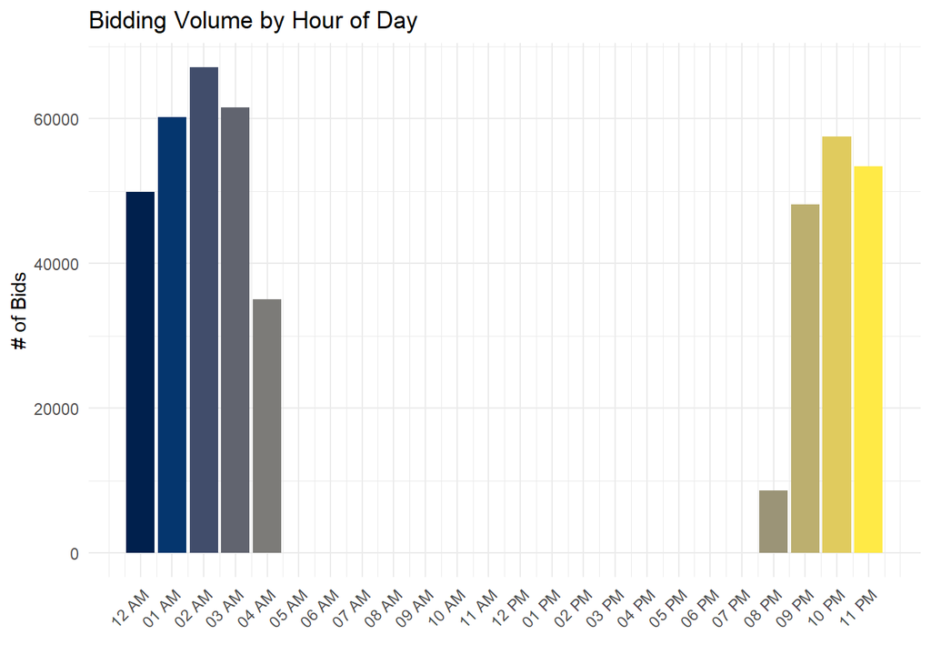

```r
# Extract hour and day of week
bids_clean <- bids_clean %>%
  mutate(
    hour = hour(TIMESTAMP_clean),
    day_of_week = wday(TIMESTAMP_clean, label = TRUE, abbr = FALSE, week_start = 1),

    day_of_week = factor(day_of_week,
                         levels = c("Monday", "Tuesday", "Wednesday", "Thursday", "Friday", "Saturday", "Sunday"),
                         ordered = FALSE)
  )

# Summarize bid volume by hour
hourly_volume <- bids_clean %>%
  count(hour)


all_days <- factor(
  c("Monday", "Tuesday", "Wednesday", "Thursday", "Friday", "Saturday", "Sunday"),
  levels = c("Monday", "Tuesday", "Wednesday", "Thursday", "Friday", "Saturday", "Sunday"),
  ordered = FALSE
)

# Summarize bid volume by day of week (include 0s)
daily_volume <- bids_clean %>%
  count(day_of_week) %>%
  complete(day_of_week = all_days, fill = list(n = 0))

# Plot: Bidding volume by hour
ggplot(hourly_volume, aes(x = hour, y = n, fill = as.factor(hour))) +
  geom_col(show.legend = FALSE) +
  scale_x_continuous(
    breaks = 0:23,
    labels = format(strptime(0:23, format = "%H"), format = "%I %p")
  ) +
  scale_fill_viridis_d(option = "cividis") +
  labs(
    title = "Bidding Volume by Hour of Day",
    x = "",
    y = "# of Bids"
  ) +
  theme_minimal() +
  theme(axis.text.x = element_text(angle = 45, hjust = 1))
```

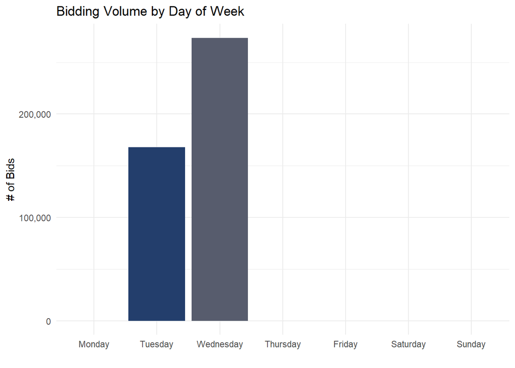

```r
# Plot: Bidding volume by day of week
ggplot(daily_volume, aes(x = day_of_week, y = n, fill = day_of_week)) +
  geom_col(show.legend = FALSE) +
  scale_y_continuous(labels = label_comma()) +
  scale_fill_viridis_d(option = "cividis") +
  labs(
    title = "Bidding Volume by Day of Week",
    x = "",
    y = "# of Bids"
  ) +
  theme_minimal()
```

Comments: At first I thought there was something wrong since we are only seeing results from a Tuesday and Wednesday, but after investigation, the original data set given to use only has data from 10/21/2025 and 10/22/2025, so this makes sense. This will limit the conclusions we can draw from the data, but it is not error.

Note: For the plots I intentionally added a minimal theme and made sure that the color schemes added were color-blind friendly and accessible. Specifically “cividis” is most optimized for all types of vision, including grayscale.

***When are the peak bidding periods, and what might explain those spikes?**

```r
# Identify top 3 bidding hours
top_hours <- hourly_volume %>%
  top_n(3, n) %>%
  arrange(desc(n))

# Identify peak day(s)
top_days <- daily_volume %>%
  top_n(1, n)

print(top_hours)
```

```
## # A tibble: 3 × 2
##    hour     n
##   <int> <int>
## 1     2 67111
## 2     3 61514
## 3     1 60233
```

```r
print(top_days)
```

```
## # A tibble: 1 × 2
##   day_of_week      n
##   <fct>        <int>
## 1 Wednesday   273779
```

Wednesday had the highest volume with 273,779 bids, but again we only have data from two days of the week so that does not mean much here.

### 0.0.6 **2. Bid Behavior & Competitiveness**

## 0.1 Price difference between winning and losing bids

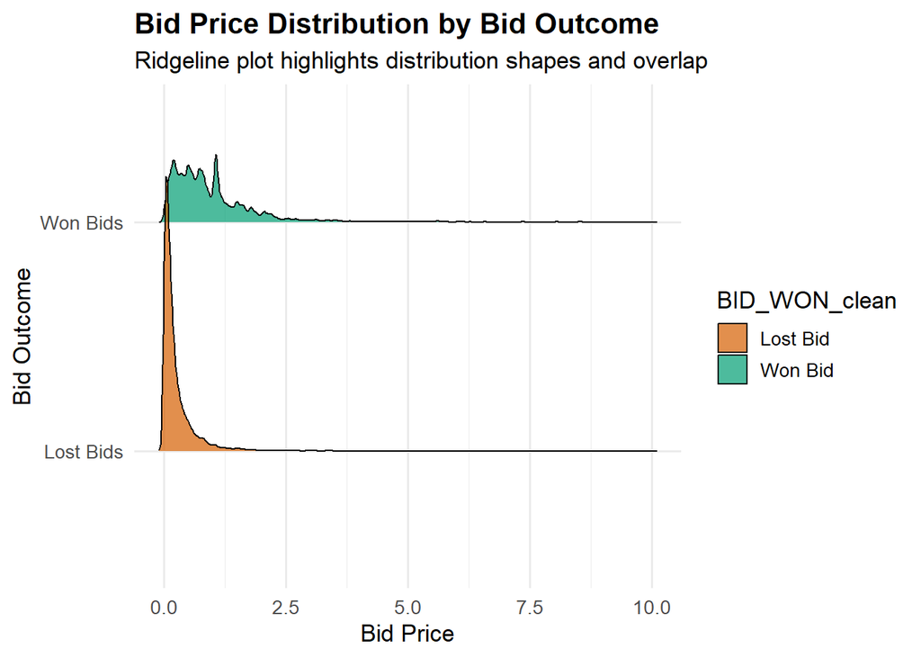

```r
# Ridgeline plot of price distributions for won vs lost bids

ggplot(bids_clean, aes(y = BID_WON_clean, x = PRICE_final, fill = BID_WON_clean)) +
  geom_density_ridges(alpha = 0.7, scale = 1.2) +      # ridge density curves
  scale_fill_manual(
    values = c("FALSE" = "#D55E00", "TRUE" = "#009E73"), # custom colors
    labels = c("Lost Bid", "Won Bid")                    # legend labels
  ) +
  labs(
    title = "Bid Price Distribution by Bid Outcome",      # plot title
    subtitle = "Ridgeline plot highlights distribution shapes and overlap",
    x = "Bid Price",                                      # x-axis label
    y = "Bid Outcome"                                     # y-axis label
  ) +
  scale_y_discrete(labels = c("FALSE" = "Lost Bids", "TRUE" = "Won Bids")) +
  theme_minimal(base_size = 13) +                         # clean theme
  theme(plot.title = element_text(face = "bold"))         # bold title
```

### 0.1.1 Figure summary

The ridgeline plot gives a clear picture of how bid prices differ between winning and losing bids. Most losing bids are packed tightly at the lower end of the price range, while winning bids tend to extend into slightly higher prices. There is some overlap at very low bid amounts, but overall the curve for winning bids stretches farther to the right. This pattern suggests that higher bid prices generally improve the chances of winning.

## 0.2 Violin - Boxplot bid outcome representation

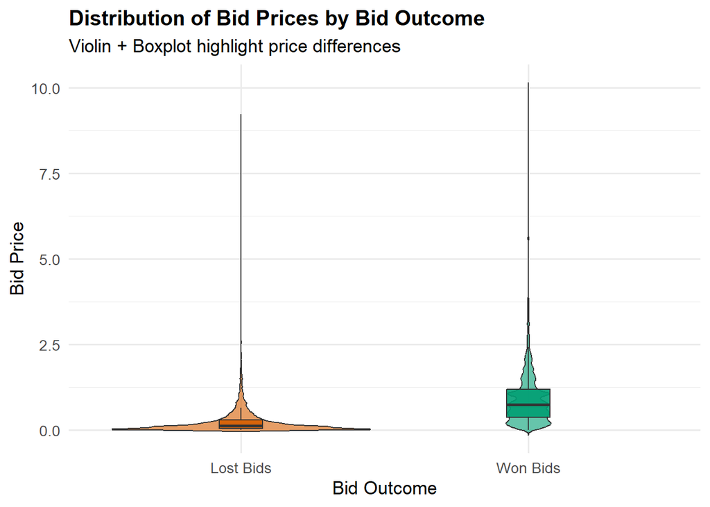

```r
# Violin + Boxplot comparing bid prices for wins vs losses

ggplot(bids_clean, aes(x = BID_WON_clean, y = PRICE_final, fill = BID_WON_clean)) +
  geom_violin(trim = FALSE, alpha = 0.6) +                 # violin shows price distribution shape
  geom_boxplot(width = 0.15, outlier.shape = NA, alpha = 0.9) +  # boxplot shows median + IQR
  scale_fill_manual(
    values = c("FALSE" = "#D55E00", "TRUE" = "#009E73"),   # custom colors
    labels = c("Lost Bid", "Won Bid"),                     # legend labels
    name = "Bid Outcome"
  ) +
  labs(
    title = "Distribution of Bid Prices by Bid Outcome",    # plot title
    subtitle = "Violin + Boxplot highlight price differences",
    x = "Bid Outcome",
    y = "Bid Price"
  ) +
  scale_x_discrete(labels = c("FALSE" = "Lost Bids", "TRUE" = "Won Bids")) +
  theme_minimal(base_size = 13) +                           # clean theme
  theme(
    plot.title = element_text(face = "bold", size = 15),    # bold title
    strip.text = element_text(face = "bold"),
    legend.position = "none"                                # hide legend (labels on x-axis)
  )
```

### 0.2.1 Figure summary

The violin–boxplot shows clear differences in how bid prices behave for winning and losing bids. Losing bids are mostly concentrated at very low prices, with only a few stretching upward. In contrast, winning bids tend to be higher overall, with a wider spread and a noticeably higher median. While there is still some overlap at the lower end, the shape of the distributions shows that higher bid prices are much more common among winning bids. Overall, the plot suggests that bidding slightly more greatly improves the odds of winning.

## 0.3 Publishers bidding trends

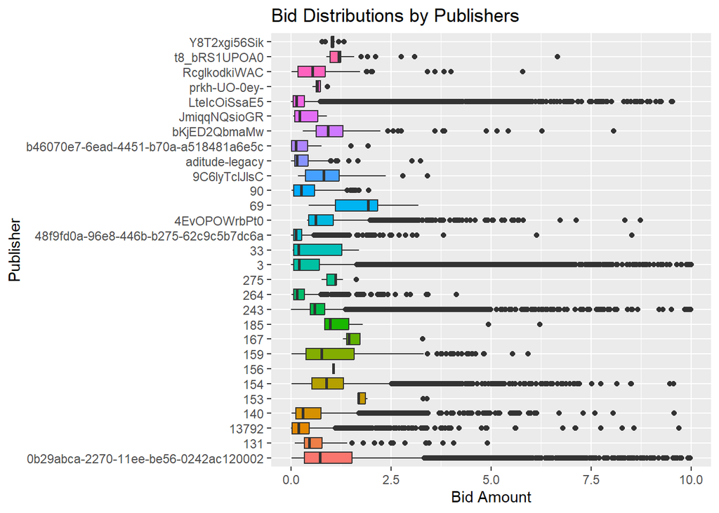

```r
# Boxplot of price distribution across advertisers

ggplot(bids_clean, aes(x = factor(PUBLISHER_ID), y = PRICE_final,
                       fill = factor(PUBLISHER_ID))) +
  geom_boxplot(show.legend = FALSE) +     # boxplots for each advertiser
  coord_flip() +                          # horizontal orientation for readability
  labs(
    title = "Bid Distributions by Publishers",
    x = "Publisher",
    y = "Bid Amount"
  )
```

### 0.3.1 Figure summary

The boxplot highlights how bidding behavior varies widely across advertisers. Some advertisers place consistently low and tightly clustered bids, while others submit much higher bids with a broader spread. Several advertisers show long tails and many outliers, indicating occasional aggressive bidding. A few advertisers also stand out with significantly higher median bid values compared to the rest. Overall, the plot shows that bidding strategies differ substantially across advertisers, with some adopting conservative pricing and others frequently pushing toward the upper end of the bid range.

## 0.4 Publishers spatial price representation

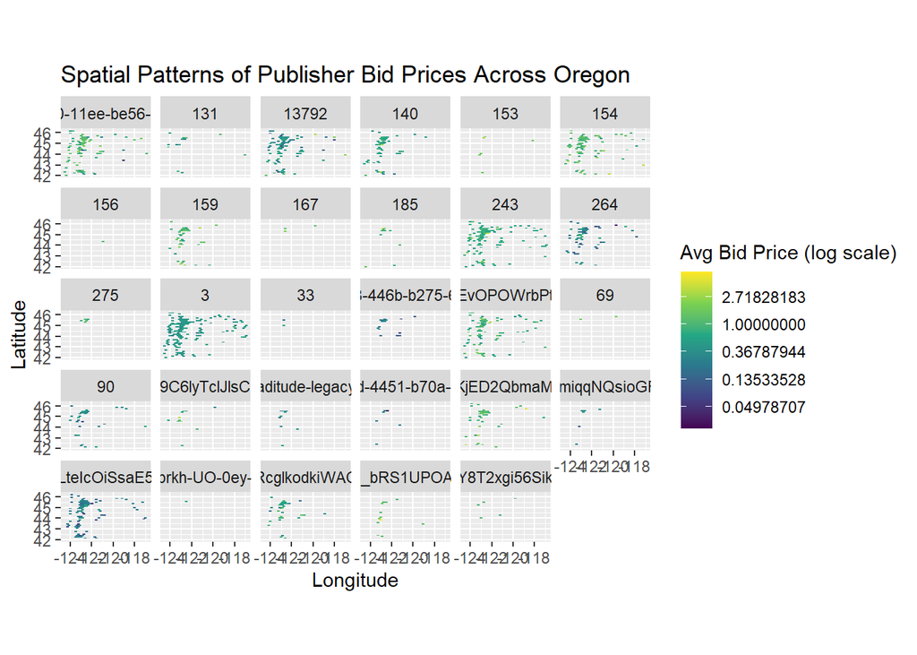

```r
# Hexbin map showing spatial bid patterns by advertiser

ggplot(bids_clean, aes(DEVICE_GEO_LONG_clean, DEVICE_GEO_LAT_clean)) +
  stat_summary_hex(aes(z = PRICE_final), fun = mean) +   # hexbin with mean price per hex
  scale_fill_viridis_c(trans = "log",                    # color scale on log scale for contrast
                       name = "Avg Bid Price (log scale)") +
  coord_equal() +                                        # preserve geographic proportions
  facet_wrap(~ PUBLISHER_ID) +                           # separate map panel per advertiser
  labs(
    title = "Spatial Patterns of Publisher Bid Prices Across Oregon",
    x = "Longitude",
    y = "Latitude"
  )
```

### 0.4.1 Plot summary

The faceted map shows how public vary not only in the prices they bid but also in where those bids appear across Oregon. Some publishers have activity spread broadly throughout the state, while others are concentrated in just a few regions. Within each publisher’s panel, the color shading highlights differences in bid intensity: lighter areas represent higher average prices, while darker areas reflect lower prices. The patterns suggest that publishers target different geographic areas and may adjust their bidding strategies depending on where users are located. Thus the map reveals distinct spatial footprints for each publisher, with both bidding levels and geographic focus varying considerably from one publisher to another.

## 0.5 Cleaning NAs for modeling

```r
# Clean binary column from the original character ones
bids_clean$BID_WON_clean <- ifelse(bids_clean$BID_WON_clean == "TRUE", 1,
                                   ifelse(bids_clean$BID_WON_clean == "FALSE", 0, NA))

# drop NAs
bids_clean <- bids_clean %>%
  filter(
    !is.na(BID_WON_clean),
    !is.na(PRICE_final),
    !is.na(DEVICE_GEO_LONG_clean),
    !is.na(DEVICE_GEO_LAT_clean)
  )
```

## 0.6 predicting win probability from price and location

```r
set.seed(123)   # ensure the train/test split is reproducible

# Determine number of rows in the dataset
n <- nrow(bids_clean)

# Randomly select 60% of rows for training
train_index <- sample(seq_len(n), size = 0.6 * n)

# Split the dataset into training and testing sets
train_data <- bids_clean[train_index, ]   # 60% training data
test_data  <- bids_clean[-train_index, ]  # remaining 40% test data

# Fit a BAM model (fast GAM) to predict win probability
model <- bam(
  BID_WON_clean ~
    s(PRICE_final, k = 10) +                            # smooth effect of bid price
    te(DEVICE_GEO_LONG_clean, DEVICE_GEO_LAT_clean,     # 2D smooth for spatial effects
       k = c(8, 8)),
  data = train_data,                                     # training dataset
  family = binomial(),                                   # binary outcome (win or lose)
  discrete = TRUE                                        # speed optimization for big data
)

summary(model)   # show model fit statistics and significance
```

```
##
## Family: binomial
## Link function: logit
##
## Formula:
## BID_WON_clean ~ s(PRICE_final, k = 10) + te(DEVICE_GEO_LONG_clean,
##     DEVICE_GEO_LAT_clean, k = c(8, 8))
##
## Parametric coefficients:
##             Estimate Std. Error z value Pr(>|z|)
## (Intercept)  1.81966    0.09377   19.41   <2e-16 ***
## ---
## Signif. codes:  0 '***' 0.001 '**' 0.01 '*' 0.05 '.' 0.1 ' ' 1
##
## Approximate significance of smooth terms:
##                                                   edf Ref.df Chi.sq p-value
## s(PRICE_final)                                  8.833  8.983  65469  <2e-16 ***
## te(DEVICE_GEO_LONG_clean,DEVICE_GEO_LAT_clean) 49.184 53.880   1445  <2e-16 ***
## ---
## Signif. codes:  0 '***' 0.001 '**' 0.01 '*' 0.05 '.' 0.1 ' ' 1
##
## R-sq.(adj) =  0.345   Deviance explained = 30.2%
## fREML = 3.5153e+05  Scale est. = 1         n = 264589
```

### 0.6.1 Model Interpretation

The model shows a strong and clear relationship between how much an advertiser bids and their chances of winning the auction. The smooth term for bid amount (s(PRICE_final)) is highly significant (p < 2e-16), meaning changes in bid price have a meaningful effect on the probability of winning. In general, higher bids increase the likelihood of winning, which aligns with how auction systems typically function.

The spatial smooth term (s(longitude, latitude)) is also significant, indicating that location matters as well—some geographic areas are naturally more competitive than others.

The model explains about 30% of the deviance and has an adjusted R-squired of 0.345, which is reasonable for behavioral auction data. Overall, the results suggest that while bid amount is a major driver of winning probability, location-based competition also plays an important role.

## 0.7 Model dicrimination accuracy

```r
# Predict on test data
test_data$pred_prob <- predict(model, newdata = test_data, type = "response")

# Compute AUC
roc_obj <- roc(test_data$BID_WON_clean, test_data$pred_prob)
auc_value <- auc(roc_obj)

print(auc_value)
```

```
## Area under the curve: 0.86
```

### 0.7.1 AUC Interpretation

The AUC of 0.86 shows that our model is very effective at separating winning and losing bids, about 86% of the time, it assigns a higher win probability to an actual winner than to a loser. This indicates strong predictive power, meaning the model is reliable for estimating competitive bid prices, identifying locations where bids tend to perform better or worse, and predicting the likelihood of winning for new bids.

## 0.8 Trend to our predicted model

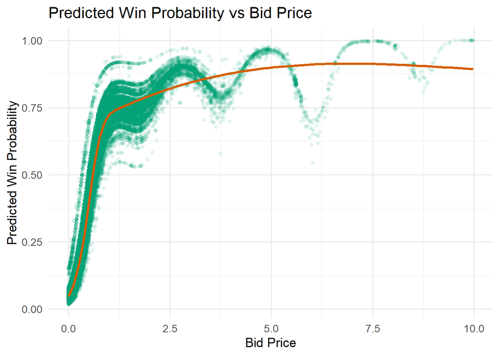

```r
# showing price in relation to probability of win or loss a bid

ggplot(test_data, aes(x = PRICE_final, y = pred_prob)) +
  geom_point(alpha = 0.1, color = "#009E73") +
  geom_smooth(color = "#D55E00", se = FALSE, size = 1.2) +
  labs(
    title = "Predicted Win Probability vs Bid Price",
    x = "Bid Price",
    y = "Predicted Win Probability"
  ) +
  theme_minimal(base_size = 13)
```

### 0.8.1 Figure summary

The figure shows how win probability changes with bid price. Win chances rise quickly at low prices, meaning small increases make a big difference. As prices move higher, the improvement slows, and eventually the probability levels off, suggesting that once a bid is competitive, raising the price further adds little benefit.

## 0.9 spatial representation of win probability across cities

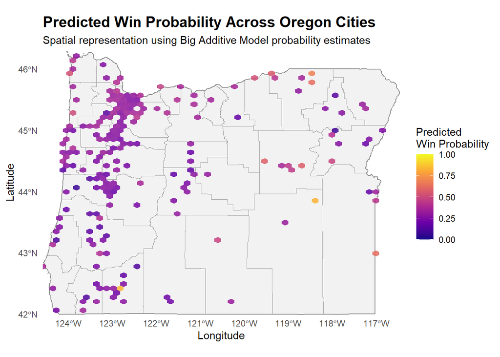

```r
# Predict win probability using your trained model
bids_clean$pred_prob <- predict(
  model,
  newdata = bids_clean,
  type = "response"
)

# Prepare data for hex plotting
bids_pred_hex <- bids_clean %>%
  mutate(
    DEVICE_GEO_LONG_clean = as.numeric(DEVICE_GEO_LONG_clean),
    DEVICE_GEO_LAT_clean  = as.numeric(DEVICE_GEO_LAT_clean)
  ) %>%
  filter(
    is.finite(DEVICE_GEO_LONG_clean),
    is.finite(DEVICE_GEO_LAT_clean),
    is.finite(pred_prob)
  )

# Oregon state outline
or_state <- states(cb = TRUE, year = 2023, class = "sf") %>%
  filter(STUSPS == "OR") %>%
  st_transform(4326)

# Counties shapefile for Oregon
or_counties <- tigris::counties(state = "OR", cb = TRUE, year = 2023, class = "sf") %>%
  sf::st_transform(4326)

# Plot Model-Predicted Win Probability

ggplot() +
  # Oregon boundary
  geom_sf(data = or_state, fill = "gray95", color = "gray50", linewidth = 0.4) +
  # Oregon counties
  geom_sf(data = or_counties, fill = NA, color = "gray60", linewidth = 0.3) +
  # Predicted win-probability hex map
  stat_summary_hex(
    data = bids_pred_hex,
    aes(
      x = DEVICE_GEO_LONG_clean,
      y = DEVICE_GEO_LAT_clean,
      z = pred_prob
    ),
    fun  = mean,
    bins = 50,
    alpha = 0.85
  ) +

  # Color scale for predictions
  scale_fill_viridis_c(
    option = "plasma",
    name   = "Predicted\nWin Probability",
    limits = c(0, 1)
  ) +
  coord_sf(expand = FALSE) +
  labs(
    title = "Predicted Win Probability Across Oregon Cities",
    subtitle = "Spatial representation using Big Additive Model probability estimates",
    x = "Longitude",
    y = "Latitude"
  ) +
  theme_minimal() +
  theme(
    panel.grid = element_blank(),
    plot.title = element_text(face = "bold", size = 15),
    plot.subtitle = element_text(size = 11),
    legend.position = "right"
  )
```

```r
# convert back to char
bids_clean$BID_WON_clean <- ifelse(bids_clean$BID_WON_clean == 1, "TRUE", "FALSE")
```

### 0.9.2 **3. Auction Outcomes**

```r
#Library
library(dplyr)
library(ggplot2)
library(tidyr)
library(corrplot)
library(lubridate)
library(forcats)
library(gridExtra)
library(ggrepel)
```

#1. Which features are most predictive of a win?

```r
cat("\n")
```

```r
cat(strrep("=", 70), "\n")
cat("Q1. WHICH FEATURES ARE MOST PREDICTIVE OF A WIN?\n")
```

```
## Q1. WHICH FEATURES ARE MOST PREDICTIVE OF A WIN?
```

```r
cat(strrep("=", 70), "\n\n")
# Convert BID_WON_clean to logical for analysis
bids_clean <- bids_clean %>%
  mutate(BID_WON_clean = as.logical(BID_WON_clean))

# 1.1 Overall win rate
win_rate <- bids_clean %>%
  summarise(
    total_bids = n(),
    wins = sum(BID_WON_clean, na.rm = TRUE),
    win_rate = mean(BID_WON_clean, na.rm = TRUE)
  )

cat("Overall Win Rate:\n")
```

```
## Overall Win Rate:
```

```r
print(win_rate)
```

```
## # A tibble: 1 × 3
##   total_bids   wins win_rate
##        <int>  <int>    <dbl>
## 1     440983 120340    0.273
```

```r
cat("\n")
```

```r
# 1.2 Win rate by PRICE
cat("Win Rate by Price Quartiles:\n")
```

```
## Win Rate by Price Quartiles:
```

```r
cat(strrep("-", 70), "\n")
price_analysis <- bids_clean %>%
  filter(!is.na(PRICE_final)) %>%
  mutate(
    price_quartile = ntile(PRICE_final, 4),
    price_bucket = case_when(
      PRICE_final < 0.01 ~ "< $0.01",
      PRICE_final < 0.05 ~ "$0.01 - $0.05",
      PRICE_final < 0.10 ~ "$0.05 - $0.10",
      PRICE_final < 0.50 ~ "$0.10 - $0.50",
      PRICE_final < 1.00 ~ "$0.50 - $1.00",
      TRUE ~ "≥ $1.00"
    )
  ) %>%
  group_by(price_bucket) %>%
  summarise(
    n_bids = n(),
    win_rate = mean(BID_WON_clean, na.rm = TRUE),
    avg_price = mean(PRICE_final, na.rm = TRUE),
    median_price = median(PRICE_final, na.rm = TRUE)
  ) %>%
  arrange(desc(win_rate))

print(price_analysis)
```

```
## # A tibble: 6 × 5
##   price_bucket  n_bids  win_rate avg_price median_price
##   <chr>          <int>     <dbl>     <dbl>        <dbl>
## 1 ≥ $1.00        57676 0.785       1.73        1.45
## 2 $0.50 - $1.00  65794 0.537       0.704       0.699
## 3 $0.10 - $0.50 176971 0.195       0.241       0.21
## 4 $0.05 - $0.10  58516 0.0561      0.0718      0.07
## 5 $0.01 - $0.05  70987 0.0272      0.0247      0.022
## 6 < $0.01        11039 0.0000906   0.00273     0.000333
```

```r
cat("\n")
```

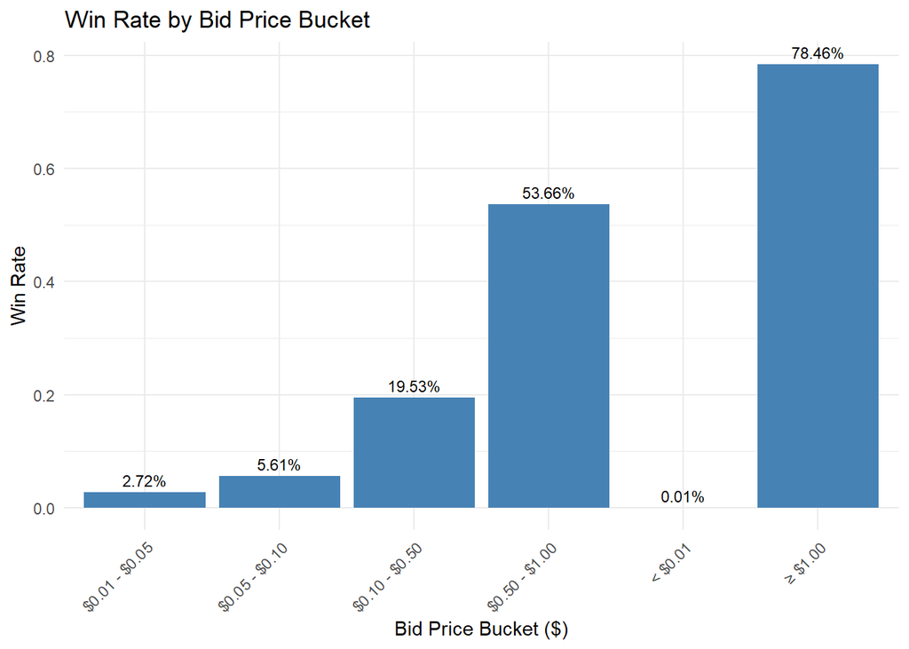

```r
# Visualize win rate by price
ggplot(price_analysis, aes(x = price_bucket, y = win_rate)) +
  geom_col(fill = "steelblue") +
  geom_text(aes(label = sprintf("%.2f%%", win_rate * 100)),
            vjust = -0.5, size = 3) +
  labs(title = "Win Rate by Bid Price Bucket",
       x = "Bid Price Bucket ($)",
       y = "Win Rate") +
  theme_minimal() +
  theme(axis.text.x = element_text(angle = 45, hjust = 1))
```

```r
# 1.3 Win rate by RESPONSE_TIME
cat("\nWin Rate by Response Time:\n")
```

```
##
## Win Rate by Response Time:
```

```r
cat(strrep("-", 70), "\n")
response_time_analysis <- bids_clean %>%
  filter(!is.na(RESPONSE_TIME_clean)) %>%
  mutate(
    response_time_bucket = case_when(
      RESPONSE_TIME_clean < 50 ~ "< 50ms",
      RESPONSE_TIME_clean < 100 ~ "50-100ms",
      RESPONSE_TIME_clean < 200 ~ "100-200ms",
      RESPONSE_TIME_clean < 500 ~ "200-500ms",
      RESPONSE_TIME_clean < 1000 ~ "500-1000ms",
      TRUE ~ "≥ 1000ms"
    )
  ) %>%
  group_by(response_time_bucket) %>%
  summarise(
    n_bids = n(),
    win_rate = mean(BID_WON_clean, na.rm = TRUE),
    avg_response_time = mean(RESPONSE_TIME_clean, na.rm = TRUE)
  ) %>%
  arrange(avg_response_time)

print(response_time_analysis)
```

```
## # A tibble: 6 × 4
##   response_time_bucket n_bids win_rate avg_response_time
##   <chr>                 <int>    <dbl>             <dbl>
## 1 < 50ms                13615    0.248              35.2
## 2 50-100ms              70588    0.289              80.7
## 3 100-200ms            188242    0.258             144.
## 4 200-500ms            152743    0.282             297.
## 5 500-1000ms            15421    0.308             632.
## 6 ≥ 1000ms                374    0.230            1288.
```

```r
cat("\n")
```

```r
# 1.4 Win rate by DEVICE_TYPE
cat("\nWin Rate by Device Type (Raw Codes):\n")
```

```
##
## Win Rate by Device Type (Raw Codes):
```

```r
cat(strrep("-", 70), "\n")
device_analysis <- bids_clean %>%
  filter(!is.na(DEVICE_TYPE_clean)) %>%
  group_by(DEVICE_TYPE_clean) %>%
  summarise(
    n_bids = n(),
    wins = sum(BID_WON_clean, na.rm = TRUE),
    win_rate = mean(BID_WON_clean, na.rm = TRUE),
    prop_of_bids = n() / nrow(bids_clean)
  ) %>%
  arrange(desc(win_rate))

print(device_analysis)
```

```
## # A tibble: 5 × 5
##   DEVICE_TYPE_clean n_bids  wins win_rate prop_of_bids
##   <chr>              <int> <int>    <dbl>        <dbl>
## 1 2                  24583 11649    0.474     0.0557
## 2 0                   3694  1366    0.370     0.00838
## 3 1                 228990 66290    0.289     0.519
## 4 5                    318    91    0.286     0.000721
## 5 4                 183398 40944    0.223     0.416
```

```r
cat("\n")
```

```r
# 1.5 Win rate by GEO_REGION (using city as proxy since all are OR)
cat("\nWin Rate by City (Top 10):\n")
```

```
##
## Win Rate by City (Top 10):
```

```r
cat(strrep("-", 70), "\n")
city_analysis <- bids_clean %>%
  filter(!is.na(DEVICE_GEO_CITY_clean)) %>%
  group_by(DEVICE_GEO_CITY_clean) %>%
  summarise(
    n_bids = n(),
    win_rate = mean(BID_WON_clean, na.rm = TRUE),
    avg_price = mean(PRICE_final, na.rm = TRUE)
  ) %>%
  filter(n_bids >= 100) %>%  # Only consider cities with sufficient data
  arrange(desc(win_rate)) %>%
  head(10)

print(city_analysis)
```

```
## # A tibble: 10 × 4
##    DEVICE_GEO_CITY_clean n_bids win_rate avg_price
##    <chr>                  <int>    <dbl>     <dbl>
##  1 Troutdale               1510    0.579     0.500
##  2 Boardman                1559    0.561     0.525
##  3 Lafayette                109    0.514     0.188
##  4 Warrenton                157    0.459     0.596
##  5 Scio                     112    0.438     0.640
##  6 Beavercreek              231    0.437     0.532
##  7 Lake Oswego             2193    0.387     0.569
##  8 Newberg                 1802    0.387     0.590
##  9 Hillsboro              13588    0.365     0.459
## 10 Saint Helens             244    0.365     0.590
```

```r
cat("\n")
```

```r
# 1.6 Win rate by TIME of DAY
cat("\nWin Rate by Time of Day - CORRECTED ANALYSIS:\n")
```

```
##
## Win Rate by Time of Day - CORRECTED ANALYSIS:
```

```r
cat(strrep("=", 70), "\n\n")
# First, let's see what hours we have in the data
cat("Hour Distribution in TIMESTAMP_clean:\n")
```

```
## Hour Distribution in TIMESTAMP_clean:
```

```r
cat(strrep("-", 70), "\n")
hour_distribution <- bids_clean %>%
  mutate(hour = hour(TIMESTAMP_clean)) %>%
  count(hour) %>%
  arrange(hour)

print(hour_distribution)
```

```
## # A tibble: 9 × 2
##    hour     n
##   <int> <int>
## 1     0 49812
## 2     1 60170
## 3     2 67025
## 4     3 61452
## 5     4 34967
## 6    20  8616
## 7    21 48085
## 8    22 57462
## 9    23 53394
```

```r
cat("\n")
```

```r
# Now analyze win rates by hour
cat("\nWin Rate by Hour of Day:\n")
```

```
##
## Win Rate by Hour of Day:
```

```r
cat(strrep("-", 70), "\n")
hourly_analysis <- bids_clean %>%
  mutate(hour = hour(TIMESTAMP_clean)) %>%
  group_by(hour) %>%
  summarise(
    n_bids = n(),
    wins = sum(BID_WON_clean, na.rm = TRUE),
    win_rate = mean(BID_WON_clean, na.rm = TRUE),
    avg_price = mean(PRICE_final, na.rm = TRUE),
    median_price = median(PRICE_final, na.rm = TRUE),
    avg_response_time = mean(RESPONSE_TIME_clean, na.rm = TRUE)
  ) %>%
  arrange(hour)

print(hourly_analysis)
```

```
## # A tibble: 9 × 7
##    hour n_bids  wins win_rate avg_price median_price avg_response_time
##   <int>  <int> <int>    <dbl>     <dbl>        <dbl>             <dbl>
## 1     0  49812 13755    0.276     0.427        0.197              211.
## 2     1  60170 16480    0.274     0.425        0.193              215.
## 3     2  67025 18041    0.269     0.423        0.192              192.
## 4     3  61452 17312    0.282     0.447        0.198              187.
## 5     4  34967  9187    0.263     0.500        0.209              201.
## 6    20   8616  2231    0.259     0.431        0.193              217.
## 7    21  48085 13231    0.275     0.451        0.2                216.
## 8    22  57462 15635    0.272     0.451        0.198              190.
## 9    23  53394 14468    0.271     0.439        0.19               202.
```

```r
cat("\n")
```

```r
# Now analyze by day part
cat("\nWin Rate by Day Part (Corrected Grouping):\n")
```

```
##
## Win Rate by Day Part (Corrected Grouping):
```

```r
cat(strrep("-", 70), "\n")
day_part_analysis <- bids_clean %>%
  mutate(
    hour = hour(TIMESTAMP_clean),
    day_part = case_when(
      hour >= 6 & hour < 12 ~ "Morning (6-12)",
      hour >= 12 & hour < 18 ~ "Afternoon (12-18)",
      hour >= 18 & hour < 24 ~ "Evening (18-24)",
      hour >= 0 & hour < 6 ~ "Night (0-6)",
      TRUE ~ "Unknown"
    )
  ) %>%
  group_by(day_part) %>%  # Only group by day_part, not hour
  summarise(
    n_bids = n(),
    wins = sum(BID_WON_clean, na.rm = TRUE),
    win_rate = mean(BID_WON_clean, na.rm = TRUE),
    avg_price = mean(PRICE_final, na.rm = TRUE),
    median_price = median(PRICE_final, na.rm = TRUE),
    avg_response_time = mean(RESPONSE_TIME_clean, na.rm = TRUE)
  ) %>%
  arrange(factor(day_part, levels = c("Night (0-6)", "Morning (6-12)",
                                      "Afternoon (12-18)", "Evening (18-24)")))

print(day_part_analysis)
```

```
## # A tibble: 2 × 7
##   day_part        n_bids  wins win_rate avg_price median_price avg_response_time
##   <chr>            <int> <int>    <dbl>     <dbl>        <dbl>             <dbl>
## 1 Night (0-6)     273426 74775    0.273     0.439        0.196              201.
## 2 Evening (18-24) 167557 45565    0.272     0.446        0.196              203.
```

```r
cat("\n")
```

```r
# 1.7 Win rate by AD SIZE
cat("\nWin Rate by Ad Size:\n")
```

```
##
## Win Rate by Ad Size:
```

```r
cat(strrep("-", 70), "\n")
size_analysis <- bids_clean %>%
  filter(!is.na(SIZE)) %>%
  group_by(SIZE) %>%
  summarise(
    n_bids = n(),
    win_rate = mean(BID_WON_clean, na.rm = TRUE),
    avg_price = mean(PRICE_final, na.rm = TRUE)
  ) %>%
  arrange(desc(win_rate))

print(size_analysis)
```

```
## # A tibble: 38 × 4
##    SIZE      n_bids win_rate avg_price
##    <chr>      <int>    <dbl>     <dbl>
##  1 1080x1080      2    1         2.64
##  2 1080x566       1    1         1.16
##  3 1140x635       3    1         1.31
##  4 320x106        2    1         1.43
##  5 750x570        1    1         6.26
##  6 320x107       14    0.857     0.789
##  7 640x480       91    0.791     0.564
##  8 1140x250       3    0.667     1.08
##  9 640x360        6    0.667     0.564
## 10 480x360        5    0.6       0.631
## # ℹ 28 more rows
```

```r
cat("\n")
```

```r
# 1.8 COMPREHENSIVE CORRELATION ANALYSIS FOR ALL FEATURES

cat("\n")
```

```r
cat(strrep("=", 70), "\n")
cat("COMPREHENSIVE CORRELATION ANALYSIS FOR ALL PREDICTORS\n")
```

```
## COMPREHENSIVE CORRELATION ANALYSIS FOR ALL PREDICTORS
```

```r
cat(strrep("=", 70), "\n\n")
# 1. CONTINUOUS VARIABLES (Pearson correlation)
cat("1. CONTINUOUS VARIABLES - PEARSON CORRELATION:\n")
```

```
## 1. CONTINUOUS VARIABLES - PEARSON CORRELATION:
```

```r
cat(strrep("-", 70), "\n")
continuous_cor <- bids_clean %>%
  mutate(
    BID_WON_numeric = as.numeric(BID_WON_clean),
    HOUR = hour(TIMESTAMP_clean)
  ) %>%
  select(BID_WON_numeric, PRICE_final, RESPONSE_TIME_clean, HOUR) %>%
  cor(use = "complete.obs")

print(round(continuous_cor, 4))
```

```
##                     BID_WON_numeric PRICE_final RESPONSE_TIME_clean    HOUR
## BID_WON_numeric              1.0000      0.4869              0.0378 -0.0019
## PRICE_final                  0.4869      1.0000              0.0558  0.0073
## RESPONSE_TIME_clean          0.0378      0.0558              1.0000  0.0009
## HOUR                        -0.0019      0.0073              0.0009  1.0000
```

```r
cat("\n")
```

```r
# 2. CATEGORICAL VARIABLES - CHI-SQUARE TESTS
cat("2. CATEGORICAL VARIABLES - CHI-SQUARE TESTS:\n")
```

```
## 2. CATEGORICAL VARIABLES - CHI-SQUARE TESTS:
```

```r
cat(strrep("-", 70), "\n")
# Function to calculate Cramer's V (effect size for chi-square)
cramers_v <- function(chi_result, n, k) {
  sqrt(chi_result$statistic / (n * (min(k) - 1)))
}

# A. Device Type
cat("A. DEVICE TYPE:\n")
```

```
## A. DEVICE TYPE:
```

```r
device_table <- table(bids_clean$DEVICE_TYPE_clean, bids_clean$BID_WON_clean)
chi_device <- chisq.test(device_table)
v_device <- cramers_v(chi_device, nrow(bids_clean), dim(device_table))
cat(sprintf("  Chi-square = %.2f, df = %d, p-value = %.6f\n",
            chi_device$statistic, chi_device$parameter, chi_device$p.value))
```

```
##   Chi-square = 7774.52, df = 4, p-value = 0.000000
```

```r
cat(sprintf("  Cramer's V (effect size) = %.4f\n", v_device))
```

```
##   Cramer's V (effect size) = 0.1328
```

```r
cat("  Interpretation:", ifelse(v_device > 0.1, "Small effect", "Negligible effect"), "\n\n")
```

```
##   Interpretation: Small effect
```

```r
# B. Top 10 Cities (for reliability)
cat("B. GEOGRAPHY (Top 10 Cities by volume):\n")
```

```
## B. GEOGRAPHY (Top 10 Cities by volume):
```

```r
top_cities <- bids_clean %>%
  count(DEVICE_GEO_CITY_clean) %>%
  arrange(desc(n)) %>%
  head(10) %>%
  pull(DEVICE_GEO_CITY_clean)

city_data <- bids_clean %>%
  filter(DEVICE_GEO_CITY_clean %in% top_cities)

city_table <- table(city_data$DEVICE_GEO_CITY_clean, city_data$BID_WON_clean)
chi_city <- chisq.test(city_table)
v_city <- cramers_v(chi_city, nrow(city_data), dim(city_table))
cat(sprintf("  Chi-square = %.2f, df = %d, p-value = %.6f\n",
            chi_city$statistic, chi_city$parameter, chi_city$p.value))
```

```
##   Chi-square = 1078.88, df = 9, p-value = 0.000000
```

```r
cat(sprintf("  Cramer's V (effect size) = %.4f\n", v_city))
```

```
##   Cramer's V (effect size) = 0.0548
```

```r
cat("  Interpretation:", ifelse(v_city > 0.1, "Small effect", "Negligible effect"), "\n\n")
```

```
##   Interpretation: Negligible effect
```

```r
# C. Common Ad Sizes
cat("C. AD SIZE (Common sizes with n ≥ 1000):\n")
```

```
## C. AD SIZE (Common sizes with n ≥ 1000):
```

```r
common_sizes <- bids_clean %>%
  count(SIZE) %>%
  filter(n >= 1000) %>%
  pull(SIZE)

size_data <- bids_clean %>%
  filter(SIZE %in% common_sizes)

size_table <- table(size_data$SIZE, size_data$BID_WON_clean)
chi_size <- chisq.test(size_table)
v_size <- cramers_v(chi_size, nrow(size_data), dim(size_table))
cat(sprintf("  Chi-square = %.2f, df = %d, p-value = %.6f\n",
            chi_size$statistic, chi_size$parameter, chi_size$p.value))
```

```
##   Chi-square = 9035.29, df = 5, p-value = 0.000000
```

```r
cat(sprintf("  Cramer's V (effect size) = %.4f\n", v_size))
```

```
##   Cramer's V (effect size) = 0.1437
```

```r
cat("  Interpretation:", ifelse(v_size > 0.1, "Small effect", "Negligible effect"), "\n\n")
```

```
##   Interpretation: Small effect
```

```r
# 3. ORDINAL/INTERVAL VARIABLES
cat("3. ORDINAL/INTERVAL VARIABLES:\n")
```

```
## 3. ORDINAL/INTERVAL VARIABLES:
```

```r
cat(strrep("-", 70), "\n")
# Day Part (ordinal)
cat("A. DAY PART (Morning/Afternoon/Evening/Night):\n")
```

```
## A. DAY PART (Morning/Afternoon/Evening/Night):
```

```r
day_part_data <- bids_clean %>%
  mutate(
    DAY_PART = factor(case_when(
      hour(TIMESTAMP_clean) >= 6 & hour(TIMESTAMP_clean) < 12 ~ 1,
      hour(TIMESTAMP_clean) >= 12 & hour(TIMESTAMP_clean) < 18 ~ 2,
      hour(TIMESTAMP_clean) >= 18 & hour(TIMESTAMP_clean) < 24 ~ 3,
      hour(TIMESTAMP_clean) >= 0 & hour(TIMESTAMP_clean) < 6 ~ 4
    ), levels = 1:4, labels = c("Morning", "Afternoon", "Evening", "Night"))
  ) %>%
  filter(!is.na(DAY_PART))

# Kruskal-Wallis test (non-parametric ANOVA)
kruskal_day <- kruskal.test(as.numeric(BID_WON_clean) ~ DAY_PART, data = day_part_data)
cat(sprintf("  Kruskal-Wallis H = %.2f, df = %d, p-value = %.6f\n",
            kruskal_day$statistic, kruskal_day$parameter, kruskal_day$p.value))
```

```
##   Kruskal-Wallis H = 1.24, df = 1, p-value = 0.266052
```

```r
# Eta squared for effect size
eta_sq_day <- (kruskal_day$statistic - kruskal_day$parameter) /
  (nrow(day_part_data) - kruskal_day$parameter - 1)
cat(sprintf("  Eta squared (effect size) = %.4f\n", eta_sq_day))
```

```
##   Eta squared (effect size) = 0.0000
```

```r
cat("  Interpretation:", ifelse(eta_sq_day > 0.01, "Small effect", "Negligible effect"), "\n\n")
```

```
##   Interpretation: Negligible effect
```

```r
# 4. COMPARISON TABLE
cat("4. FEATURE IMPORTANCE COMPARISON TABLE:\n")
```

```
## 4. FEATURE IMPORTANCE COMPARISON TABLE:
```

```r
cat(strrep("-", 70), "\n")
```

```r
importance_table <- data.frame(
  Feature = c("Price", "Response Time", "Device Type", "Geography (City)",
              "Ad Size", "Time of Day (Hour)", "Day Part"),
  Test = c("Pearson r", "Pearson r", "Cramer's V", "Cramer's V",
           "Cramer's V", "Point-biserial r", "Eta squared"),
  Effect_Size = c(
    continuous_cor[1, 2],  # Price
    continuous_cor[1, 3],  # Response Time
    v_device,              # Device Type
    v_city,                # Geography
    v_size,                # Ad Size
    continuous_cor[1, 4],  # Hour
    eta_sq_day             # Day Part
  ),
  P_Value = c(
    cor.test(as.numeric(bids_clean$BID_WON_clean), bids_clean$PRICE_final)$p.value,
    cor.test(as.numeric(bids_clean$BID_WON_clean), bids_clean$RESPONSE_TIME_clean)$p.value,
    chi_device$p.value,
    chi_city$p.value,
    chi_size$p.value,
    cor.test(as.numeric(bids_clean$BID_WON_clean), hour(bids_clean$TIMESTAMP_clean))$p.value,
    kruskal_day$p.value
  ),
  Interpretation = c("", "", "", "", "", "", "")
)

# Add interpretation
importance_table <- importance_table %>%
  mutate(
    Interpretation = case_when(
      abs(Effect_Size) >= 0.5 ~ "VERY STRONG",
      abs(Effect_Size) >= 0.3 ~ "STRONG",
      abs(Effect_Size) >= 0.1 ~ "MODERATE",
      abs(Effect_Size) >= 0.05 ~ "WEAK",
      abs(Effect_Size) >= 0.01 ~ "VERY WEAK",
      TRUE ~ "NEGLIGIBLE"
    ),
    P_Value_Sig = ifelse(P_Value < 0.001, "***",
                        ifelse(P_Value < 0.01, "**",
                              ifelse(P_Value < 0.05, "*", "ns")))
  )

print(importance_table %>% arrange(desc(abs(Effect_Size))))
```

```
##              Feature             Test   Effect_Size       P_Value
## 1              Price        Pearson r  4.869437e-01  0.000000e+00
## 2            Ad Size       Cramer's V  1.437026e-01  0.000000e+00
## 3        Device Type       Cramer's V  1.327779e-01  0.000000e+00
## 4   Geography (City)       Cramer's V  5.484673e-02 1.668369e-226
## 5      Response Time        Pearson r  3.781010e-02 3.219628e-139
## 6 Time of Day (Hour) Point-biserial r -1.932262e-03  1.994408e-01
## 7           Day Part      Eta squared  5.374157e-07  2.660519e-01
##   Interpretation P_Value_Sig
## 1         STRONG         ***
## 2       MODERATE         ***
## 3       MODERATE         ***
## 4           WEAK         ***
## 5      VERY WEAK         ***
## 6     NEGLIGIBLE          ns
## 7     NEGLIGIBLE          ns
```

```r
cat("\n")
```

```r
# 5. VISUALIZATION
cat("5. VISUALIZING FEATURE IMPORTANCE:\n")
```

```
## 5. VISUALIZING FEATURE IMPORTANCE:
```

```r
cat(strrep("-", 70), "\n")
```

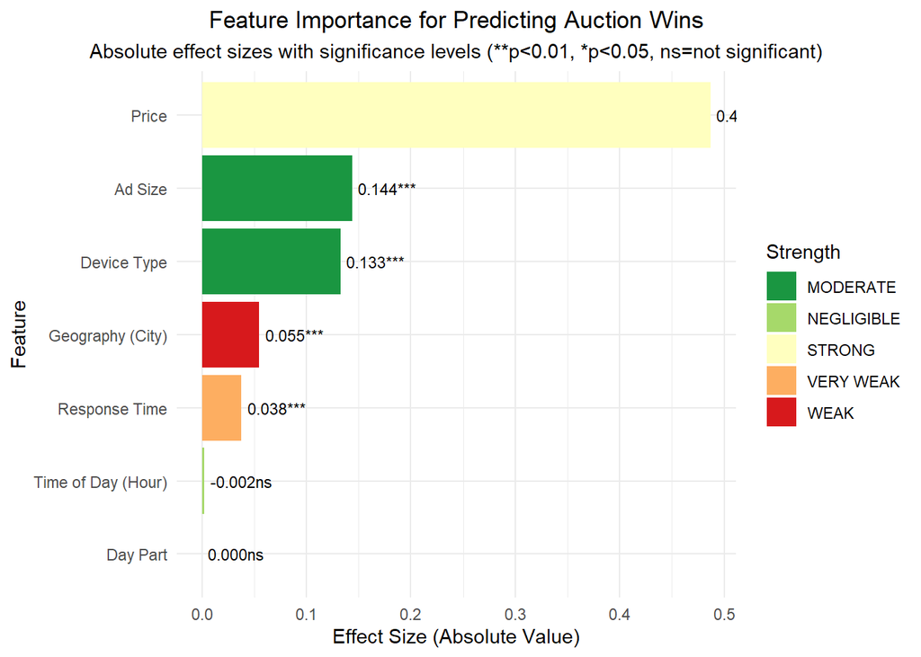

```r
# Effect size comparison plot
ggplot(importance_table, aes(x = reorder(Feature, abs(Effect_Size)),
                            y = abs(Effect_Size), fill = Interpretation)) +
  geom_bar(stat = "identity") +
  geom_text(aes(label = sprintf("%.3f%s", Effect_Size, P_Value_Sig)),
            hjust = -0.1, size = 3) +
  coord_flip() +
  scale_fill_brewer(palette = "RdYlGn", direction = -1) +
  labs(title = "Feature Importance for Predicting Auction Wins",
       subtitle = "Absolute effect sizes with significance levels (**p<0.01, *p<0.05, ns=not significant)",
       x = "Feature",
       y = "Effect Size (Absolute Value)",
       fill = "Strength") +
  theme_minimal() +
  theme(plot.title = element_text(hjust = 0.5),
        plot.subtitle = element_text(hjust = 0.5))
```

```r
cat("Visualization created.\n")
```

```
## Visualization created.
```

conclusion Q1: Price is most Predictive of Win.

#2. Systematic differences across devices, regions, or ad categories

```r
cat("\n")
```

```r
cat(strrep("=", 70), "\n")
cat(strrep("=", 70), "\n\n")
# PART 1: DEVICE TYPE DIFFERENCES

cat("1. DEVICE TYPE SYSTEMATIC DIFFERENCES\n")
```

```
## 1. DEVICE TYPE SYSTEMATIC DIFFERENCES
```

```r
cat(strrep("=", 70), "\n\n")
# 1.1 Comprehensive device analysis using raw DEVICE_TYPE_clean
cat("1.1 Device Type Performance Metrics (Raw Codes):\n")
```

```
## 1.1 Device Type Performance Metrics (Raw Codes):
```

```r
cat(strrep("-", 70), "\n")
device_comprehensive <- bids_clean %>%
  filter(!is.na(DEVICE_TYPE_clean)) %>%
  group_by(DEVICE_TYPE_clean) %>%
  summarise(
    n_bids = n(),
    bid_share = n() / nrow(bids_clean) * 100,
    wins = sum(BID_WON_clean, na.rm = TRUE),
    win_rate = mean(BID_WON_clean, na.rm = TRUE) * 100,
    avg_bid_price = mean(PRICE_final, na.rm = TRUE),
    median_bid_price = median(PRICE_final, na.rm = TRUE),
    avg_response_time = mean(RESPONSE_TIME_clean, na.rm = TRUE),
    std_dev_price = sd(PRICE_final, na.rm = TRUE),
    price_iqr = IQR(PRICE_final, na.rm = TRUE),
    # Winning price metrics
    avg_winning_price = mean(PRICE_final[BID_WON_clean], na.rm = TRUE),
    avg_losing_price = mean(PRICE_final[!BID_WON_clean], na.rm = TRUE),
    price_premium = avg_winning_price - avg_losing_price,
    # Additional metrics
    min_price = min(PRICE_final, na.rm = TRUE),
    max_price = max(PRICE_final, na.rm = TRUE),
    q25_price = quantile(PRICE_final, 0.25, na.rm = TRUE),
    q75_price = quantile(PRICE_final, 0.75, na.rm = TRUE)
  ) %>%
  arrange(desc(win_rate))

print(device_comprehensive)
```

```
## # A tibble: 5 × 17
##   DEVICE_TYPE_clean n_bids bid_share  wins win_rate avg_bid_price
##   <chr>              <int>     <dbl> <int>    <dbl>         <dbl>
## 1 2                  24583    5.57   11649     47.4         0.696
## 2 0                   3694    0.838   1366     37.0         0.589
## 3 1                 228990   51.9    66290     28.9         0.493
## 4 5                    318    0.0721    91     28.6         1.01
## 5 4                 183398   41.6    40944     22.3         0.340
## # ℹ 11 more variables: median_bid_price <dbl>, avg_response_time <dbl>,
## #   std_dev_price <dbl>, price_iqr <dbl>, avg_winning_price <dbl>,
## #   avg_losing_price <dbl>, price_premium <dbl>, min_price <dbl>,
## #   max_price <dbl>, q25_price <dbl>, q75_price <dbl>
```

```r
cat("\n")
```

```r
# 1.2 Device type statistical tests
cat("1.2 Statistical Tests for Device Differences:\n")
```

```
## 1.2 Statistical Tests for Device Differences:
```

```r
cat(strrep("-", 70), "\n")
# Filter for device types with sufficient data
device_types_sufficient <- device_comprehensive %>%
  filter(n_bids >= 100) %>%
  pull(DEVICE_TYPE_clean)

device_test_data <- bids_clean %>%
  filter(DEVICE_TYPE_clean %in% device_types_sufficient) %>%
  mutate(DEVICE_TYPE_clean = factor(DEVICE_TYPE_clean))

# ANOVA for price differences
if (length(device_types_sufficient) >= 2) {
  price_anova <- aov(PRICE_final ~ DEVICE_TYPE_clean, data = device_test_data)
  cat("ANOVA - Price Differences by Device Type:\n")
  print(summary(price_anova))

  # Post-hoc test if significant
  if (summary(price_anova)[[1]]$`Pr(>F)`[1] < 0.05) {
    cat("\nTukey HSD Post-hoc Test (Price):\n")
    print(TukeyHSD(price_anova))
  }
}
```

```
## ANOVA - Price Differences by Device Type:
##                       Df Sum Sq Mean Sq F value Pr(>F)
## DEVICE_TYPE_clean      4   4301  1075.4    2542 <2e-16 ***
## Residuals         440978 186530     0.4
## ---
## Signif. codes:  0 '***' 0.001 '**' 0.01 '*' 0.05 '.' 0.1 ' ' 1
##
## Tukey HSD Post-hoc Test (Price):
##   Tukey multiple comparisons of means
##     95% family-wise confidence level
##
## Fit: aov(formula = PRICE_final ~ DEVICE_TYPE_clean, data = device_test_data)
##
## $DEVICE_TYPE_clean
##            diff        lwr         upr p adj
## 1-0 -0.09546857 -0.1248925 -0.06604463     0
## 2-0  0.10746212  0.0761563  0.13876794     0
## 4-0 -0.24930849 -0.2787904 -0.21982655     0
## 5-0  0.41973091  0.3160514  0.52341037     0
## 2-1  0.20293069  0.1910238  0.21483763     0
## 4-1 -0.15383992 -0.1593992 -0.14828060     0
## 5-1  0.51519948  0.4156447  0.61475425     0
## 4-2 -0.35677061 -0.3688202 -0.34472105     0
## 5-2  0.31226879  0.2121417  0.41239590     0
## 5-4  0.66903940  0.5694675  0.76861133     0
```

```r
# Kruskal-Wallis test for win rate
win_kruskal <- kruskal.test(as.numeric(BID_WON_clean) ~ DEVICE_TYPE_clean,
                           data = device_test_data)
cat("\nKruskal-Wallis Test - Win Rate Differences by Device Type:\n")
```

```
##
## Kruskal-Wallis Test - Win Rate Differences by Device Type:
```

```r
cat(sprintf("H = %.2f, p-value = %.6f\n",
            win_kruskal$statistic, win_kruskal$p.value))
```

```
## H = 7774.50, p-value = 0.000000
```

```r
# Chi-square test for win distribution
device_contingency <- table(device_test_data$DEVICE_TYPE_clean,
                           device_test_data$BID_WON_clean)
chi_device <- chisq.test(device_contingency)
cat("\nChi-square Test - Win Distribution by Device Type:\n")
```

```
##
## Chi-square Test - Win Distribution by Device Type:
```

```r
cat(sprintf("X-squared = %.2f, df = %d, p-value = %.6f\n",
            chi_device$statistic, chi_device$parameter, chi_device$p.value))
```

```
## X-squared = 7774.52, df = 4, p-value = 0.000000
```

```r
cat("\n")
```

```r
# 1.3 Device type time patterns
cat("1.3 Device Usage Patterns by Time of Day:\n")
```

```
## 1.3 Device Usage Patterns by Time of Day:
```

```r
cat(strrep("-", 70), "\n")
device_time_patterns <- bids_clean %>%
  filter(DEVICE_TYPE_clean %in% device_types_sufficient) %>%
  mutate(
    hour = hour(TIMESTAMP_clean),
    day_part = case_when(
      hour >= 6 & hour < 12 ~ "Morning",
      hour >= 12 & hour < 18 ~ "Afternoon",
      hour >= 18 & hour < 24 ~ "Evening",
      hour >= 0 & hour < 6 ~ "Night"
    )
  ) %>%
  group_by(DEVICE_TYPE_clean, day_part) %>%
  summarise(
    n_bids = n(),
    share_of_device = n() / sum(n()) * 100,
    win_rate = mean(BID_WON_clean, na.rm = TRUE) * 100,
    avg_price = mean(PRICE_final, na.rm = TRUE),
    avg_response = mean(RESPONSE_TIME_clean, na.rm = TRUE),
    .groups = 'drop'
  ) %>%
  pivot_wider(
    names_from = day_part,
    values_from = c(n_bids, share_of_device, win_rate, avg_price, avg_response)
  )

print(device_time_patterns)
```

```
## # A tibble: 5 × 11
##   DEVICE_TYPE_clean n_bids_Evening n_bids_Night share_of_device_Evening
##   <chr>                      <int>        <int>                   <dbl>
## 1 0                           1151         2543                     100
## 2 1                          70555       158435                     100
## 3 2                          11641        12942                     100
## 4 4                          84101        99297                     100
## 5 5                            109          209                     100
## # ℹ 7 more variables: share_of_device_Night <dbl>, win_rate_Evening <dbl>,
## #   win_rate_Night <dbl>, avg_price_Evening <dbl>, avg_price_Night <dbl>,
## #   avg_response_Evening <dbl>, avg_response_Night <dbl>
```

```r
cat("\n")
```

```r
# PART 2: REGIONAL DIFFERENCES (RAW DATA)

cat("\n2. REGIONAL (GEOGRAPHIC) SYSTEMATIC DIFFERENCES\n")
```

```
##
## 2. REGIONAL (GEOGRAPHIC) SYSTEMATIC DIFFERENCES
```

```r
cat(strrep("=", 70), "\n\n")
# 2.1 City-level comprehensive analysis using raw DEVICE_GEO_CITY_clean
cat("2.1 Top 15 Cities by Bid Volume:\n")
```

```
## 2.1 Top 15 Cities by Bid Volume:
```

```r
cat(strrep("-", 70), "\n")
city_top15 <- bids_clean %>%
  filter(!is.na(DEVICE_GEO_CITY_clean)) %>%
  group_by(DEVICE_GEO_CITY_clean) %>%
  summarise(
    n_bids = n(),
    wins = sum(BID_WON_clean, na.rm = TRUE),
    win_rate = mean(BID_WON_clean, na.rm = TRUE) * 100,
    avg_price = mean(PRICE_final, na.rm = TRUE),
    median_price = median(PRICE_final, na.rm = TRUE),
    avg_response_time = mean(RESPONSE_TIME_clean, na.rm = TRUE),
    mobile_pct = mean(DEVICE_TYPE_clean == "1", na.rm = TRUE) * 100,
    desktop_pct = mean(DEVICE_TYPE_clean == "4", na.rm = TRUE) * 100,
    device_2_pct = mean(DEVICE_TYPE_clean == "2", na.rm = TRUE) * 100,
    # Price distribution metrics
    price_sd = sd(PRICE_final, na.rm = TRUE),
    price_min = min(PRICE_final, na.rm = TRUE),
    price_max = max(PRICE_final, na.rm = TRUE),
    price_q1 = quantile(PRICE_final, 0.25, na.rm = TRUE),
    price_q3 = quantile(PRICE_final, 0.75, na.rm = TRUE),
    price_iqr = price_q3 - price_q1,
    # Winning metrics
    winning_avg_price = mean(PRICE_final[BID_WON_clean], na.rm = TRUE),
    losing_avg_price = mean(PRICE_final[!BID_WON_clean], na.rm = TRUE),
    .groups = 'drop'
  ) %>%
  filter(n_bids >= 100) %>%
  mutate(
    price_cv = price_sd / avg_price * 100
  ) %>%
  arrange(desc(n_bids)) %>%
  head(15)

print(city_top15)
```

```
## # A tibble: 15 × 19
##    DEVICE_GEO_CITY_clean n_bids  wins win_rate avg_price median_price
##    <chr>                  <int> <int>    <dbl>     <dbl>        <dbl>
##  1 Portland              264038 69082     26.2     0.416        0.19
##  2 Salem                  14357  3871     27.0     0.471        0.22
##  3 Beaverton              13991  4051     29.0     0.499        0.21
##  4 Hillsboro              13588  4963     36.5     0.459        0.205
##  5 Medford                11637  2637     22.7     0.386        0.18
##  6 Eugene                  9962  2675     26.9     0.492        0.2
##  7 Gresham                 9935  3234     32.6     0.506        0.226
##  8 Bend                    7215  1907     26.4     0.478        0.226
##  9 Grants Pass             7181  1635     22.8     0.365        0.16
## 10 Oregon City             6748  1898     28.1     0.450        0.193
## 11 Springfield             4006   950     23.7     0.461        0.2
## 12 Corvallis               3939  1067     27.1     0.498        0.222
## 13 Roseburg                3288   788     24.0     0.471        0.216
## 14 McMinnville             3078   904     29.4     0.505        0.208
## 15 Albany                  2560   705     27.5     0.545        0.303
## # ℹ 13 more variables: avg_response_time <dbl>, mobile_pct <dbl>,
## #   desktop_pct <dbl>, device_2_pct <dbl>, price_sd <dbl>, price_min <dbl>,
## #   price_max <dbl>, price_q1 <dbl>, price_q3 <dbl>, price_iqr <dbl>,
## #   winning_avg_price <dbl>, losing_avg_price <dbl>, price_cv <dbl>
```

```r
cat("\n")
```

```r
# 2.2 Regional statistical tests
cat("2.2 Statistical Tests for Regional Differences:\n")
```

```
## 2.2 Statistical Tests for Regional Differences:
```

```r
cat(strrep("-", 70), "\n")
# Select top 5 cities for analysis
top5_cities <- city_top15 %>%
  head(5) %>%
  pull(DEVICE_GEO_CITY_clean)

regional_test_data <- bids_clean %>%
  filter(DEVICE_GEO_CITY_clean %in% top5_cities) %>%
  mutate(city = factor(DEVICE_GEO_CITY_clean))

# ANOVA for price differences
if (n_distinct(regional_test_data$city) >= 2) {
  regional_price_anova <- aov(PRICE_final ~ city, data = regional_test_data)
  cat("ANOVA - Price Differences by City:\n")
  print(summary(regional_price_anova))

  if (summary(regional_price_anova)[[1]]$`Pr(>F)`[1] < 0.05) {
    cat("\nTukey HSD Post-hoc Test (Regional Price Differences):\n")
    print(TukeyHSD(regional_price_anova))
  }
}
```

```
## ANOVA - Price Differences by City:
##                 Df Sum Sq Mean Sq F value Pr(>F)
## city             4    158   39.52    94.8 <2e-16 ***
## Residuals   317606 132415    0.42
## ---
## Signif. codes:  0 '***' 0.001 '**' 0.01 '*' 0.05 '.' 0.1 ' ' 1
##
## Tukey HSD Post-hoc Test (Regional Price Differences):
##   Tukey multiple comparisons of means
##     95% family-wise confidence level
##
## Fit: aov(formula = PRICE_final ~ city, data = regional_test_data)
##
## $city
##                            diff          lwr          upr     p adj
## Hillsboro-Beaverton -0.03955246 -0.060766308 -0.018338615 0.0000036
## Medford-Beaverton   -0.11221559 -0.134313175 -0.090118008 0.0000000
## Portland-Beaverton  -0.08243941 -0.097719287 -0.067159539 0.0000000
## Salem-Beaverton     -0.02801229 -0.048935937 -0.007088651 0.0024173
## Medford-Hillsboro   -0.07266313 -0.094909012 -0.050417249 0.0000000
## Portland-Hillsboro  -0.04288695 -0.058380518 -0.027393385 0.0000000
## Salem-Hillsboro      0.01154017 -0.009540034  0.032620368 0.5668374
## Portland-Medford     0.02977618  0.013093059  0.046459299 0.0000111
## Salem-Medford        0.08420330  0.062233983  0.106172612 0.0000000
## Salem-Portland       0.05442712  0.039333341  0.069520897 0.0000000
```

```r
# Kruskal-Wallis for win rate differences
regional_win_kruskal <- kruskal.test(as.numeric(BID_WON_clean) ~ city,
                                    data = regional_test_data)
cat("\nKruskal-Wallis Test - Win Rate Differences by City:\n")
```

```
##
## Kruskal-Wallis Test - Win Rate Differences by City:
```

```r
cat(sprintf("H = %.2f, p-value = %.6f\n",
            regional_win_kruskal$statistic, regional_win_kruskal$p.value))
```

```
## H = 843.47, p-value = 0.000000
```

```r
# Chi-square for win distribution
regional_contingency <- table(regional_test_data$city,
                             regional_test_data$BID_WON_clean)
chi_region <- chisq.test(regional_contingency)
cat("\nChi-square Test - Win Distribution by City:\n")
```

```
##
## Chi-square Test - Win Distribution by City:
```

```r
cat(sprintf("X-squared = %.2f, df = %d, p-value = %.6f\n",
            chi_region$statistic, chi_region$parameter, chi_region$p.value))
```

```
## X-squared = 843.48, df = 4, p-value = 0.000000
```

```r
cat("\n")
```

```r
# 2.3 City performance by device type
cat("2.3 City Performance by Device Type:\n")
```

```
## 2.3 City Performance by Device Type:
```

```r
cat(strrep("-", 70), "\n")
city_device_performance <- bids_clean %>%
  filter(DEVICE_GEO_CITY_clean %in% top5_cities &
         DEVICE_TYPE_clean %in% device_types_sufficient) %>%
  group_by(DEVICE_GEO_CITY_clean, DEVICE_TYPE_clean) %>%
  summarise(
    n_bids = n(),
    win_rate = mean(BID_WON_clean, na.rm = TRUE) * 100,
    avg_price = mean(PRICE_final, na.rm = TRUE),
    avg_response = mean(RESPONSE_TIME_clean, na.rm = TRUE),
    .groups = 'drop'
  ) %>%
  pivot_wider(
    names_from = DEVICE_TYPE_clean,
    values_from = c(n_bids, win_rate, avg_price, avg_response),
    names_sep = "_"
  )

print(city_device_performance)
```

```
## # A tibble: 5 × 21
##   DEVICE_GEO_CITY_clean n_bids_0 n_bids_1 n_bids_2 n_bids_4 n_bids_5 win_rate_0
##   <chr>                    <int>    <int>    <int>    <int>    <int>      <dbl>
## 1 Beaverton                  111     9481     1016     3376        7       35.1
## 2 Hillsboro                  161     7516     1035     4847       29       52.8
## 3 Medford                    130     5727      378     5402       NA       45.4
## 4 Portland                  1105   115609    11386   135757      181       41.6
## 5 Salem                       91     7967     1026     5260       13       31.9
## # ℹ 14 more variables: win_rate_1 <dbl>, win_rate_2 <dbl>, win_rate_4 <dbl>,
## #   win_rate_5 <dbl>, avg_price_0 <dbl>, avg_price_1 <dbl>, avg_price_2 <dbl>,
## #   avg_price_4 <dbl>, avg_price_5 <dbl>, avg_response_0 <dbl>,
## #   avg_response_1 <dbl>, avg_response_2 <dbl>, avg_response_4 <dbl>,
## #   avg_response_5 <dbl>
```

```r
cat("\n")
```

```r
# PART 3: AD SIZE DIFFERENCES (RAW DATA)

cat("\n3. AD SIZE SYSTEMATIC DIFFERENCES\n")
```

```
##
## 3. AD SIZE SYSTEMATIC DIFFERENCES
```

```r
cat(strrep("=", 70), "\n\n")
# 3.1 Ad size comprehensive analysis using raw SIZE
cat("3.1 Top 20 Ad Sizes by Volume:\n")
```

```
## 3.1 Top 20 Ad Sizes by Volume:
```

```r
cat(strrep("-", 70), "\n")
size_analysis <- bids_clean %>%
  filter(!is.na(SIZE)) %>%
  group_by(SIZE) %>%
  summarise(
    n_bids = n(),
    wins = sum(BID_WON_clean, na.rm = TRUE),
    win_rate = mean(BID_WON_clean, na.rm = TRUE) * 100,
    avg_price = mean(PRICE_final, na.rm = TRUE),
    median_price = median(PRICE_final, na.rm = TRUE),
    avg_response_time = mean(RESPONSE_TIME_clean, na.rm = TRUE),
    price_sd = sd(PRICE_final, na.rm = TRUE),
    # Device distribution
    mobile_pct = mean(DEVICE_TYPE_clean == "1", na.rm = TRUE) * 100,
    desktop_pct = mean(DEVICE_TYPE_clean == "4", na.rm = TRUE) * 100,
    device_2_pct = mean(DEVICE_TYPE_clean == "2", na.rm = TRUE) * 100,
    # Price range
    min_price = min(PRICE_final, na.rm = TRUE),
    max_price = max(PRICE_final, na.rm = TRUE),
    q25_price = quantile(PRICE_final, 0.25, na.rm = TRUE),
    q75_price = quantile(PRICE_final, 0.75, na.rm = TRUE),
    .groups = 'drop'
  ) %>%
  filter(n_bids >= 10) %>%
  arrange(desc(n_bids)) %>%
  head(20)

print(size_analysis)
```

```
## # A tibble: 20 × 15
##    SIZE  n_bids  wins win_rate avg_price median_price avg_response_time price_sd
##    <chr>  <int> <int>    <dbl>     <dbl>        <dbl>             <dbl>    <dbl>
##  1 320x… 266955 60003    22.5      0.346        0.16               192.   0.544
##  2 300x… 131340 46134    35.1      0.626        0.34               218.   0.801
##  3 300x…  22532  6292    27.9      0.339        0.196              194.   0.431
##  4 300x…   7263  2870    39.5      0.735        0.524              232.   0.918
##  5 728x…   6955  2786    40.1      0.562        0.239              216.   0.876
##  6 970x…   2490  1280    51.4      0.786        0.536              240.   1.03
##  7 0x0      900   307    34.1      0.308        0.306              131.   0.218
##  8 300x…    319    21     6.58     0.152        0.120              284.   0.111
##  9 325x…    312    50    16.0      0.309        0.102              356.   0.756
## 10 160x…    277   161    58.1      0.635        0.45               200.   0.586
## 11 300x…    261    33    12.6      0.323        0.122              278.   0.487
## 12 336x…    258    93    36.0      0.379        0.165              227.   0.513
## 13 468x…    226    51    22.6      0.203        0.124              188.   0.217
## 14 320x…    204    17     8.33     0.265        0.112              245.   0.551
## 15 1237…    162    40    24.7      0.359        0.122              440.   0.825
## 16 620x…    160    32    20        0.524        0.122              335.   1.04
## 17 970x…    136    38    27.9      0.617        0.265              346.   0.920
## 18 640x…     91    72    79.1      0.564        0.54               187.   0.388
## 19 1x1       52    19    36.5      0.498        0.167              170.   0.944
## 20 320x…     15     4    26.7      0.271        0.258              110.   0.0586
## # ℹ 7 more variables: mobile_pct <dbl>, desktop_pct <dbl>, device_2_pct <dbl>,
## #   min_price <dbl>, max_price <dbl>, q25_price <dbl>, q75_price <dbl>
```

```r
cat("\n")
```

```r
# 3.2 Statistical tests for size differences
cat("3.2 Statistical Tests for Size Differences:\n")
```

```
## 3.2 Statistical Tests for Size Differences:
```

```r
cat(strrep("-", 70), "\n")
# Test for common sizes (n >= 1000)
common_sizes <- size_analysis %>%
  filter(n_bids >= 1000) %>%
  pull(SIZE)

if (length(common_sizes) >= 2) {
  size_test_data <- bids_clean %>%
    filter(SIZE %in% common_sizes) %>%
    mutate(SIZE = factor(SIZE))

  # ANOVA for price differences
  size_price_anova <- aov(PRICE_final ~ SIZE, data = size_test_data)
  cat("ANOVA - Price Differences by Ad Size:\n")
  print(summary(size_price_anova))

  # Kruskal-Wallis for win rate
  size_win_kruskal <- kruskal.test(as.numeric(BID_WON_clean) ~ SIZE,
                                  data = size_test_data)
  cat("\nKruskal-Wallis Test - Win Rate Differences by Ad Size:\n")
  cat(sprintf("H = %.2f, p-value = %.6f\n",
              size_win_kruskal$statistic, size_win_kruskal$p.value))

  # Chi-square for win distribution
  size_contingency <- table(size_test_data$SIZE,
                           size_test_data$BID_WON_clean)
  chi_size <- chisq.test(size_contingency)
  cat("\nChi-square Test - Win Distribution by Ad Size:\n")
  cat(sprintf("X-squared = %.2f, df = %d, p-value = %.6f\n",
              chi_size$statistic, chi_size$parameter, chi_size$p.value))
}
```

```
## ANOVA - Price Differences by Ad Size:
##                 Df Sum Sq Mean Sq F value Pr(>F)
## SIZE             5   8165  1633.1    3936 <2e-16 ***
## Residuals   437529 181521     0.4
## ---
## Signif. codes:  0 '***' 0.001 '**' 0.01 '*' 0.05 '.' 0.1 ' ' 1
##
## Kruskal-Wallis Test - Win Rate Differences by Ad Size:
## H = 9035.27, p-value = 0.000000
##
## Chi-square Test - Win Distribution by Ad Size:
## X-squared = 9035.29, df = 5, p-value = 0.000000
```

```r
cat("\n")
```

```r
# 3.3 Size performance by device type
cat("3.3 Size Performance by Device Type (Common Sizes):\n")
```

```
## 3.3 Size Performance by Device Type (Common Sizes):
```

```r
cat(strrep("-", 70), "\n")
if (length(common_sizes) >= 1) {
  size_device_performance <- bids_clean %>%
    filter(SIZE %in% common_sizes[1:3] &  # Top 3 common sizes
           DEVICE_TYPE_clean %in% device_types_sufficient) %>%
    group_by(SIZE, DEVICE_TYPE_clean) %>%
    summarise(
      n_bids = n(),
      win_rate = mean(BID_WON_clean, na.rm = TRUE) * 100,
      avg_price = mean(PRICE_final, na.rm = TRUE),
      avg_response = mean(RESPONSE_TIME_clean, na.rm = TRUE),
      .groups = 'drop'
    ) %>%
    pivot_wider(
      names_from = DEVICE_TYPE_clean,
      values_from = c(n_bids, win_rate, avg_price, avg_response),
      names_sep = "_"
    )

  print(size_device_performance)
}
```

```
## # A tibble: 3 × 21
##   SIZE    n_bids_0 n_bids_1 n_bids_2 n_bids_4 n_bids_5 win_rate_0 win_rate_1
##   <chr>      <int>    <int>    <int>    <int>    <int>      <dbl>      <dbl>
## 1 300x250     1418   106050    10524    13030      318       40.9       33.9
## 2 300x50        NA      323        4    22205       NA       NA         37.8
## 3 320x50       528   120513      238   145676       NA       28.2       24.3
## # ℹ 13 more variables: win_rate_2 <dbl>, win_rate_4 <dbl>, win_rate_5 <dbl>,
## #   avg_price_0 <dbl>, avg_price_1 <dbl>, avg_price_2 <dbl>, avg_price_4 <dbl>,
## #   avg_price_5 <dbl>, avg_response_0 <dbl>, avg_response_1 <dbl>,
## #   avg_response_2 <dbl>, avg_response_4 <dbl>, avg_response_5 <dbl>
```

```r
cat("\n")
```

```r
# PART 5: TIME-BASED ANALYSIS

cat("\n5. TIME-BASED SYSTEMATIC DIFFERENCES\n")
```

```
##
## 5. TIME-BASED SYSTEMATIC DIFFERENCES
```

```r
cat(strrep("=", 70), "\n\n")
# 5.1 Hour of day analysis
cat("5.1 Hourly Analysis of Auction Performance:\n")
```

```
## 5.1 Hourly Analysis of Auction Performance:
```

```r
cat(strrep("-", 70), "\n")
hourly_analysis <- bids_clean %>%
  mutate(hour = hour(TIMESTAMP_clean)) %>%
  group_by(hour) %>%
  summarise(
    n_bids = n(),
    wins = sum(BID_WON_clean, na.rm = TRUE),
    win_rate = mean(BID_WON_clean, na.rm = TRUE) * 100,
    avg_price = mean(PRICE_final, na.rm = TRUE),
    median_price = median(PRICE_final, na.rm = TRUE),
    avg_response = mean(RESPONSE_TIME_clean, na.rm = TRUE),
    mobile_pct = mean(DEVICE_TYPE_clean == "1", na.rm = TRUE) * 100,
    desktop_pct = mean(DEVICE_TYPE_clean == "4", na.rm = TRUE) * 100,
    .groups = 'drop'
  ) %>%
  arrange(hour)

print(hourly_analysis)
```

```
## # A tibble: 9 × 9
##    hour n_bids  wins win_rate avg_price median_price avg_response mobile_pct
##   <int>  <int> <int>    <dbl>     <dbl>        <dbl>        <dbl>      <dbl>
## 1     0  49812 13755     27.6     0.427        0.197         211.       47.4
## 2     1  60170 16480     27.4     0.425        0.193         215.       56.6
## 3     2  67025 18041     26.9     0.423        0.192         192.       61.5
## 4     3  61452 17312     28.2     0.447        0.198         187.       63.0
## 5     4  34967  9187     26.3     0.500        0.209         201.       59.5
## 6    20   8616  2231     25.9     0.431        0.193         217.       34.9
## 7    21  48085 13231     27.5     0.451        0.2           216.       40.7
## 8    22  57462 15635     27.2     0.451        0.198         190.       40.1
## 9    23  53394 14468     27.1     0.439        0.19          202.       46.7
## # ℹ 1 more variable: desktop_pct <dbl>
```

```r
cat("\n")
```

```r
# 5.2 Day of week analysis
cat("5.2 Day of Week Analysis:\n")
```

```
## 5.2 Day of Week Analysis:
```

```r
cat(strrep("-", 70), "\n")
weekday_analysis <- bids_clean %>%
  mutate(
    weekday = wday(DATE_UTC_clean, label = TRUE, abbr = FALSE),
    weekday_num = wday(DATE_UTC_clean)
  ) %>%
  group_by(weekday, weekday_num) %>%
  summarise(
    n_bids = n(),
    wins = sum(BID_WON_clean, na.rm = TRUE),
    win_rate = mean(BID_WON_clean, na.rm = TRUE) * 100,
    avg_price = mean(PRICE_final, na.rm = TRUE),
    median_price = median(PRICE_final, na.rm = TRUE),
    avg_response = mean(RESPONSE_TIME_clean, na.rm = TRUE),
    .groups = 'drop'
  ) %>%
  arrange(weekday_num)

print(weekday_analysis %>% select(-weekday_num))
```

```
## # A tibble: 2 × 7
##   weekday   n_bids  wins win_rate avg_price median_price avg_response
##   <ord>      <int> <int>    <dbl>     <dbl>        <dbl>        <dbl>
## 1 Tuesday   167557 45565     27.2     0.446        0.196         203.
## 2 Wednesday 273426 74775     27.3     0.439        0.196         201.
```

```r
cat("\n")
```

```r
# 5.3 Time-based statistical tests
cat("5.3 Statistical Tests for Time Differences:\n")
```

```
## 5.3 Statistical Tests for Time Differences:
```

```r
cat(strrep("-", 70), "\n")
# Prepare data for time analysis
time_data <- bids_clean %>%
  mutate(
    hour = hour(TIMESTAMP_clean),
    day_part = case_when(
      hour >= 6 & hour < 12 ~ "Morning",
      hour >= 12 & hour < 18 ~ "Afternoon",
      hour >= 18 & hour < 24 ~ "Evening",
      hour >= 0 & hour < 6 ~ "Night"
    )
  )

# ANOVA for price by day part
if (n_distinct(time_data$day_part) >= 2) {
  time_price_anova <- aov(PRICE_final ~ day_part, data = time_data)
  cat("ANOVA - Price Differences by Time of Day:\n")
  print(summary(time_price_anova))
}
```

```
## ANOVA - Price Differences by Time of Day:
##                 Df Sum Sq Mean Sq F value   Pr(>F)
## day_part         1      5   4.987   11.52 0.000687 ***
## Residuals   440981 190826   0.433
## ---
## Signif. codes:  0 '***' 0.001 '**' 0.01 '*' 0.05 '.' 0.1 ' ' 1
```

```r
# Kruskal-Wallis for win rate by day part
time_win_kruskal <- kruskal.test(as.numeric(BID_WON_clean) ~ day_part, data = time_data)
cat("\nKruskal-Wallis Test - Win Rate Differences by Time of Day:\n")
```

```
##
## Kruskal-Wallis Test - Win Rate Differences by Time of Day:
```

```r
cat(sprintf("H = %.2f, p-value = %.6f\n",
            time_win_kruskal$statistic, time_win_kruskal$p.value))
```

```
## H = 1.24, p-value = 0.266052
```

```r
cat("\n")
```

```r
# PART 6: MULTIVARIATE ANALYSIS

cat("\n6. MULTIVARIATE ANALYSIS\n")
```

```
##
## 6. MULTIVARIATE ANALYSIS
```

```r
cat(strrep("=", 70), "\n\n")
# 6.1 Prepare data for modeling
cat("6.1 Linear Model: Factors Affecting Bid Price\n")
```

```
## 6.1 Linear Model: Factors Affecting Bid Price
```

```r
cat(strrep("-", 70), "\n")
# Create modeling dataset with raw variables
model_data <- bids_clean %>%
  filter(!is.na(PRICE_final) &
         !is.na(DEVICE_TYPE_clean) &
         !is.na(DEVICE_GEO_CITY_clean) &
         !is.na(SIZE)) %>%
  # Create indicator variables
  mutate(
    Type_one = as.numeric(DEVICE_TYPE_clean == "1"),
    Type_four = as.numeric(DEVICE_TYPE_clean == "4"),
    Type_two = as.numeric(DEVICE_TYPE_clean == "2"),
    in_top_city = as.numeric(DEVICE_GEO_CITY_clean %in% top5_cities),
    is_common_size = as.numeric(SIZE %in% common_sizes[1:3]),
    hour_of_day = hour(TIMESTAMP_clean),
    log_price = log(PRICE_final + 0.001),
    log_response = log(RESPONSE_TIME_clean + 1)
  ) %>%
  # Take a sample if data is too large
  { if (nrow(.) > 50000) sample_n(., 50000) else . }

# Fit linear model for price
if (nrow(model_data) > 100) {
  price_model <- lm(log_price ~ Type_one + Type_four +
                 Type_two + in_top_city + is_common_size
                 + hour_of_day + log_response, data = model_data)

  cat("Linear Model Summary (Log Price):\n")
  print(summary(price_model))
}
```

```
## Linear Model Summary (Log Price):
##
## Call:
## lm(formula = log_price ~ Type_one + Type_four + Type_two + in_top_city +
##     is_common_size + hour_of_day + log_response, data = model_data)
##
## Residuals:
##     Min      1Q  Median      3Q     Max
## -5.5990 -0.8826  0.1124  1.1257  4.2095
##
## Coefficients:
##                 Estimate Std. Error t value Pr(>|t|)
## (Intercept)    -2.733646   0.093403 -29.267  < 2e-16 ***
## Type_one       -0.132065   0.073363  -1.800   0.0718 .
## Type_four      -0.394705   0.073679  -5.357 8.50e-08 ***
## Type_two        0.080548   0.076175   1.057   0.2903
## in_top_city    -0.007368   0.015717  -0.469   0.6392
## is_common_size -0.025515   0.042220  -0.604   0.5456
## hour_of_day     0.004708   0.000708   6.649 2.98e-11 ***
## log_response    0.239119   0.011057  21.625  < 2e-16 ***
## ---
## Signif. codes:  0 '***' 0.001 '**' 0.01 '*' 0.05 '.' 0.1 ' ' 1
##
## Residual standard error: 1.531 on 49992 degrees of freedom
## Multiple R-squared:  0.02088,    Adjusted R-squared:  0.02075
## F-statistic: 152.3 on 7 and 49992 DF,  p-value: < 2.2e-16
```

```r
# 6.2 Logistic regression for win probability
cat("\n6.2 Logistic Regression: Factors Affecting Win Probability\n")
```

```
##
## 6.2 Logistic Regression: Factors Affecting Win Probability
```

```r
cat(strrep("-", 70), "\n")
if (nrow(model_data) > 100) {
  win_model <- glm(BID_WON_clean ~ PRICE_final + Type_one
                   + Type_four + Type_two + in_top_city +
                     is_common_size + hour_of_day +
                     RESPONSE_TIME_clean, family = binomial(), data = model_data)

  cat("Logistic Model Summary (Win Probability):\n")
  print(summary(win_model))

  # Calculate odds ratios
  odds_ratios <- exp(coef(win_model))
  cat("\nOdds Ratios (Multiplicative Effect on Win Odds):\n")
  print(round(odds_ratios, 3))
}
```

```
## Logistic Model Summary (Win Probability):
##
## Call:
## glm(formula = BID_WON_clean ~ PRICE_final + Type_one + Type_four +
##     Type_two + in_top_city + is_common_size + hour_of_day + RESPONSE_TIME_clean,
##     family = binomial(), data = model_data)
##
## Coefficients:
##                       Estimate Std. Error z value Pr(>|z|)
## (Intercept)         -2.354e+00  1.288e-01 -18.278  < 2e-16 ***
## PRICE_final          2.636e+00  2.976e-02  88.581  < 2e-16 ***
## Type_one            -2.665e-01  1.239e-01  -2.151 0.031506 *
## Type_four           -2.026e-01  1.248e-01  -1.624 0.104374
## Type_two             6.602e-01  1.277e-01   5.170 2.34e-07 ***
## in_top_city          1.100e-01  2.771e-02   3.971 7.15e-05 ***
## is_common_size       2.751e-01  7.109e-02   3.869 0.000109 ***
## hour_of_day         -2.914e-03  1.245e-03  -2.340 0.019259 *
## RESPONSE_TIME_clean -3.024e-05  8.970e-05  -0.337 0.736022
## ---
## Signif. codes:  0 '***' 0.001 '**' 0.01 '*' 0.05 '.' 0.1 ' ' 1
##
## (Dispersion parameter for binomial family taken to be 1)
##
##     Null deviance: 58575  on 49999  degrees of freedom
## Residual deviance: 44112  on 49991  degrees of freedom
## AIC: 44130
##
## Number of Fisher Scoring iterations: 5
##
##
## Odds Ratios (Multiplicative Effect on Win Odds):
##         (Intercept)         PRICE_final            Type_one           Type_four
##               0.095              13.955               0.766               0.817
##            Type_two         in_top_city      is_common_size         hour_of_day
##               1.935               1.116               1.317               0.997
## RESPONSE_TIME_clean
##               1.000
```

```r
cat("\n")
```

Conclusion: The result of P-value and Odds Ratios will change a little bit during every run, since I randomly pick part of these data. But we can find that Price is highly significant systematic difference. Most Device type has significant systematic difference, but p-value of the Type_four is around alpha=0.05. Region and device size has significant systematic difference. The hour in day has less systematic difference since odds ratios is close to 1. The Response time has no systematic difference since p-value > 0.05 and odds ratios = 1

### 0.9.3 **4. Data Quality–Driven Questions**

- **How do missing or inconsistent fields (e.g., timestamps, IDs, bid amounts) influence auction outcomes or patterns?**
- **How does the cleaned dataset change our interpretation of key trends compared to the raw data?**

# 1 price

```r
library(hexbin)
library(geosphere)

bids_clean_2 <- bids_clean

col_comparison <- function(df_1, df_2, col_1, col_2, label_1 = "Before", label_2 = "After") {
  bind_rows(
    df_1 %>%
      summarise(
        mean = mean(.data[[col_1]], na.rm = TRUE),
        sd = sd(.data[[col_1]], na.rm = TRUE),
        min = min(.data[[col_1]], na.rm = TRUE),
        max = max(.data[[col_1]], na.rm = TRUE),
        n = n(),
        na_count = sum(is.na(.data[[col_1]]))
      ) %>%
      mutate(dataset = label_1, .before = 1),

    df_2 %>%
      summarise(
        mean = mean(.data[[col_2]], na.rm = TRUE),
        sd = sd(.data[[col_2]], na.rm = TRUE),
        min = min(.data[[col_2]], na.rm = TRUE),
        max = max(.data[[col_2]], na.rm = TRUE),
        n = n(),
        na_count = sum(is.na(.data[[col_2]]))
      ) %>%
      mutate(dataset = label_2, .before = 1)
  )
}

col_comparison(bids, bids_clean, "PRICE_clean", "PRICE_final")
```

```
## # A tibble: 2 × 7
##   dataset  mean    sd         min   max      n na_count
##   <chr>   <dbl> <dbl>       <dbl> <dbl>  <int>    <int>
## 1 Before  0.446 5.48  -999        141.  441535        0
## 2 After   0.442 0.658    0.000071  10.0 440983        0
```

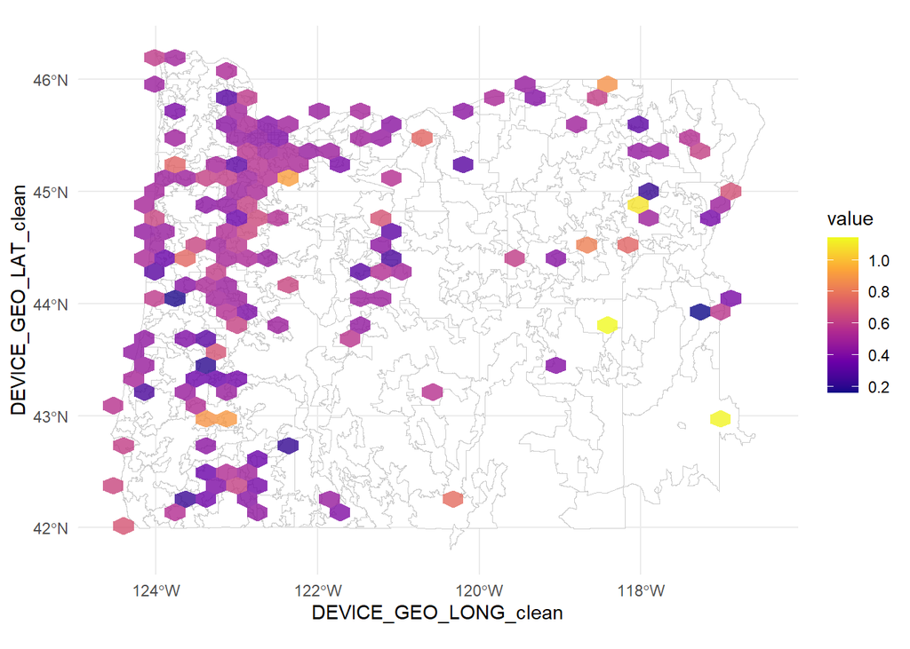

```r
#------------------------------------------------------------------------
# Group Zips into Hexes and categorize hex by city with most frequent
# zip per hex
#------------------------------------------------------------------------
bids_clean <- bids_clean_2


hb <- hexbin(
  x = bids_clean$DEVICE_GEO_LONG_clean,
  y = bids_clean$DEVICE_GEO_LAT_clean,
  xbins = 60,  # same as bins in ggplot
  IDs = TRUE
)

# Get cell assignments for each point
bids_clean$hex_id <- hb@cID
zip_city_lookup <- zipcodeR::zip_code_db %>%
  filter(state == "OR") %>%
  select(zipcode, major_city)

# Find top ZIP per hex and join city names
hex_with_city <- bids_clean %>%
  # Remove rows where hex_id or ZIP is missing
  filter(!is.na(hex_id), !is.na(DEVICE_GEO_ZIP_clean)) %>%
  # Count how many bids per hex + ZIP combination
  count(hex_id, DEVICE_GEO_ZIP_clean, name = "zip_count") %>%
  # Keep only the most frequent ZIP for each hex (1 row per hex)
  slice_max(zip_count, n = 1, by = hex_id, with_ties = FALSE) %>%
  # Attach city name by matching ZIP to zipcodeR lookup table
  left_join(zip_city_lookup, by = c("DEVICE_GEO_ZIP_clean" = "zipcode")) %>%
  # Keep only the columns we need for the final join
  select(hex_id, zip_count, major_city)

# Join to bids
bids_clean <- bids_clean %>%
  left_join(hex_with_city, by = "hex_id")

ggplot() +
  geom_sf(data = zip_code_db, fill = "white", color = "gray80") +
  stat_summary_hex(data = bids_clean,
                   aes(x = DEVICE_GEO_LONG_clean, y = DEVICE_GEO_LAT_clean, z = PRICE_final),
                   fun = mean, bins = 30, alpha = 0.8) +
  scale_fill_viridis_c(option = "plasma") +
  theme_minimal()
```

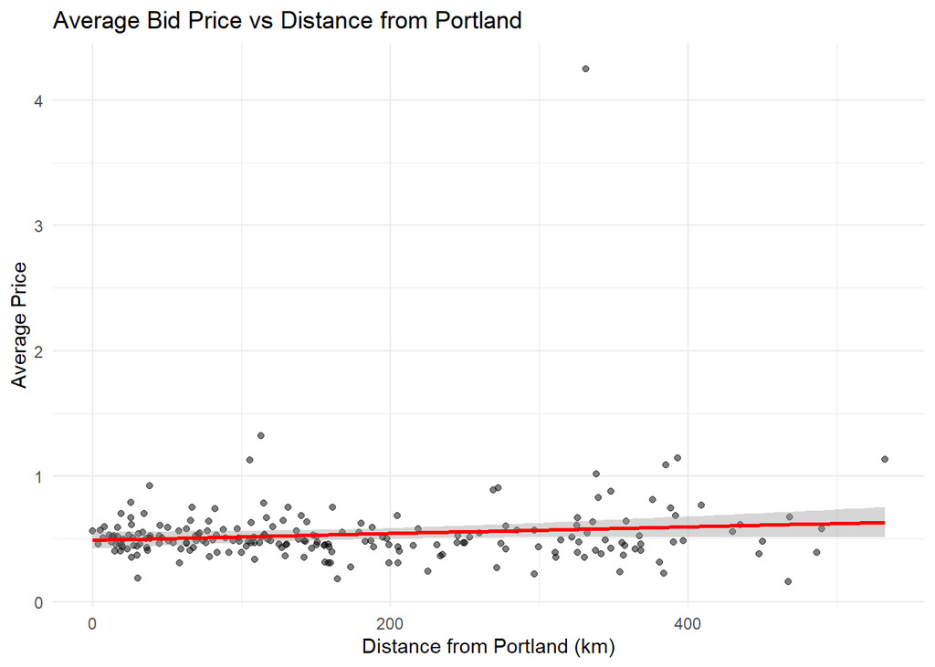

```r
#------------------------------------------------------------------------
# Calculate distance each hex is from Portland's hex
#------------------------------------------------------------------------

# Step 1: Get hex centers from the hexbin object
hex_centers <- tibble(
  hex_id = hb@cell,
  hex_x = hb@xcm,  # longitude center
  hex_y = hb@ycm   # latitude center
)

# Step 2: Find Portland's hex (by city name or coordinates)
# Option A: By city name (if you have major_city in hex_with_city)
portland_hex_id <- hex_with_city %>%
  filter(major_city == "Portland") %>%
  pull(hex_id) %>%
  first()

# Step 3: Get Portland's hex center
portland_center <- hex_centers %>%
  filter(hex_id == portland_hex_id)

hex_distances <- hex_centers %>%
  rowwise() %>%
  mutate(
    dist_to_portland_km = distHaversine(
      c(hex_x, hex_y),                              # this hex
      c(portland_center$hex_x, portland_center$hex_y)  # Portland hex
    ) / 1000  # meters to km
  ) %>%
  ungroup()

# Step 5: Join back to bids_clean
bids_clean <- bids_clean %>%
  left_join(hex_distances %>% select(hex_id, dist_to_portland_km), by = "hex_id")

# Calculate mean price per hex with distance
hex_price_distance_all <- bids_clean %>%
  filter(!is.na(dist_to_portland_km), !is.na(PRICE_final)) %>%
  group_by(hex_id, dist_to_portland_km) %>%
  summarise(
    avg_price = mean(PRICE_final, na.rm = TRUE),
    n_bids = n(),
    .groups = "drop"
  )


# Calculate mean price per hex with distance
hex_price_distance_winning <- bids_clean %>%
  filter(!is.na(dist_to_portland_km), !is.na(PRICE_final), BID_WON_clean == TRUE) %>%
  group_by(hex_id, dist_to_portland_km) %>%
  summarise(
    avg_price = mean(PRICE_final, na.rm = TRUE),
    n_bids = n(),
    .groups = "drop"
  )

p1 <- ggplot(hex_price_distance_all, aes(x = dist_to_portland_km, y = avg_price)) +
  geom_point(alpha = 0.5) +
  geom_smooth(method = "lm", se = TRUE, color = "red") +
  labs(
    title = "Average Bid Price vs Distance from Portland",
    x = "Distance from Portland (km)",
    y = "Average Price"
  ) +
  theme_minimal()

p2 <- ggplot(hex_price_distance_winning, aes(x = dist_to_portland_km, y = avg_price)) +
  geom_point(alpha = 0.5) +
  geom_smooth(method = "lm", se = TRUE, color = "red") +
  labs(
    title = "Average Winning Bid Price vs Distance from Portland",
    x = "Distance from Portland (km)",
    y = "Average Price"
  ) +
  theme_minimal()

p1
```

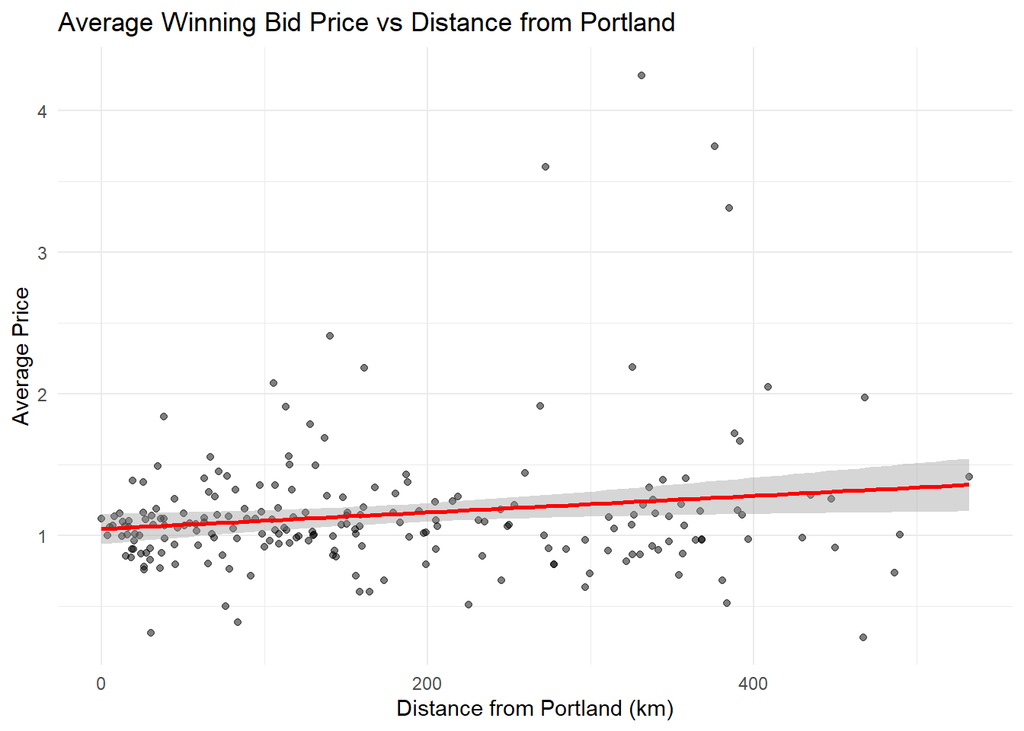

```r
p2
```

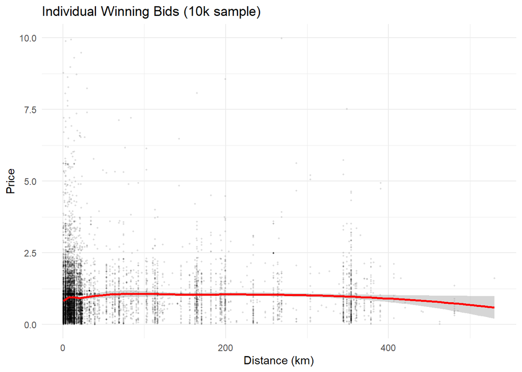

```r
#------------------------------------------------------------------------
# Calculate distance each bid lat/long is from Portland
#------------------------------------------------------------------------

# Portland center coordinates
portland_lat <- 45.52
portland_lon <- -122.68

bids_clean <- bids_clean %>%
  mutate(
    dist_to_portland_row_km = distHaversine(
      cbind(DEVICE_GEO_LONG_clean, DEVICE_GEO_LAT_clean),
      c(portland_lon, portland_lat)
    ) / 1000
  )

ggplot(bids_clean %>% filter(!is.na(dist_to_portland_km), !is.na(PRICE_final), BID_WON_clean == TRUE) %>% sample_n(10000),
             aes(x = dist_to_portland_row_km, y = PRICE_final)) +
  geom_point(alpha = 0.1, size = 0.3) +
  geom_smooth(method = "loess", color = "red") +
  labs(title = "Individual Winning Bids (10k sample)", x = "Distance (km)", y = "Price") +
  theme_minimal()
```

```r
# # dplyr summarise for multiple stats at once
# bind_rows(
#   bids %>%
#     summarise(
#       mean = mean(PRICE_clean, na.rm = TRUE),
#       sd = sd(PRICE_clean, na.rm = TRUE),
#       min = min(PRICE_clean, na.rm = TRUE),
#       max = max(PRICE_clean, na.rm = TRUE),
#       n = n(),
#       na_count = sum(is.na(PRICE_clean))
#     ) %>%
#     mutate(dataset = "Raw data (PRICE_clean, numeric) ", .before = 1),
#
#   bids_clean %>%
#     summarise(
#       mean = mean(PRICE_final, na.rm = TRUE),
#       sd = sd(PRICE_final, na.rm = TRUE),
#       min = min(PRICE_final, na.rm = TRUE),
#       max = max(PRICE_final, na.rm = TRUE),
#       n = n(),
#       na_count = sum(is.na(PRICE_final))
#     ) %>%
#     mutate(dataset = "Final Cleaned data (PRICE_final)", .before = 1)
# )

# ggplot(bids_clean, aes(x = DEVICE_GEO_LONG_clean, y = DEVICE_GEO_LAT_clean, color = PRICE_final)) +
#   geom_point(alpha = 0.3) +
#   coord_fixed(1.3)
#
#
# # Plot ZCTAs with bid locations
# ggplot() +
#   geom_sf(data = zip_code_db, fill = "white", color = "gray70") +
#   geom_point(data = bids_clean,
#              aes(x = DEVICE_GEO_LONG_clean, y = DEVICE_GEO_LAT_clean),
#              alpha = 0.2, size = 0.5, color = "steelblue") +
#   theme_minimal() +
#   labs(title = "Bid Locations in Oregon")
#
# ggplot() +
#   geom_sf(data = zip_code_db, fill = "white", color = "gray80") +
#   stat_summary_hex(data = bids_clean,
#                    aes(x = DEVICE_GEO_LONG_clean, y = DEVICE_GEO_LAT_clean, z = PRICE_final),
#                    fun = mean, bins = 30, alpha = 0.8) +
#   scale_fill_viridis_c(option = "plasma") +
#   theme_minimal()
#


#
# # Now summarize by hex
# hex_summary <- bids_clean %>%
#   group_by(hex_id) %>%
#   summarise(
#     count = n(),
#     avg_price = mean(PRICE_final, na.rm = TRUE),
#     sd_price = sd(PRICE_final, na.rm = TRUE),
#     min_price = min(PRICE_final, na.rm = TRUE),
#     max_price = max(PRICE_final, na.rm = TRUE),
#     center_long = mean(DEVICE_GEO_LONG_clean, na.rm = TRUE),
#     center_lat = mean(DEVICE_GEO_LAT_clean, na.rm = TRUE)
#   )
# hex_summary
#
#
# # Step 1: Assign hex IDs to bids
# library(hexbin)
#
# hb <- hexbin(
#   x = bids_clean$DEVICE_GEO_LONG_clean,
#   y = bids_clean$DEVICE_GEO_LAT_clean,
#   xbins = 30,
#   IDs = TRUE
# )
# bids_clean$hex_id <- hb@cID
#
# # Step 2: Find most frequent ZIP per hex
# hex_top_zip <- bids_clean %>%
#   filter(!is.na(hex_id), !is.na(DEVICE_GEO_ZIP_clean)) %>%
#   group_by(hex_id, DEVICE_GEO_ZIP_clean) %>%
#   summarise(zip_count = n(), mean = mean(.data$PRICE_final), .groups = "drop") %>%
#   group_by(hex_id) %>%
#   slice_max(zip_count, n = 1, with_ties = FALSE) %>%
#   ungroup()
#
# # Step 3: Get city names from zipcodeR
# zip_city_lookup <- zipcodeR::zip_code_db %>%
#   filter(state == "OR") %>%
#   select(zipcode, major_city)
#
# # Step 4: Join to get cities
# hex_with_city <- hex_top_zip %>%
#   left_join(zip_city_lookup, by = c("DEVICE_GEO_ZIP_clean" = "zipcode"))
#
# print(hex_with_city)
```

# 2

#Data Visualization

#Synthesis

*Notes: Things to make clear in the sythesis portion of this all for our own use:

> What were points of uncertainity? What steps did we take to address them and how could they still be showing up? How did we clean and prepare the data set for our work? What choices did we make and how did we standardize?

#Presentation Assignment:

##We will decide who is generating what info and transferring it to the slides. ##We also need to decide who will present what and how to field questions.

Final presentation ask: Your final presentation, in **20–30 minutes**, should tell a clear, professional story of your team’s data-cleaning workflow, exploratory analysis, and collaboration practices. The goal is to demonstrate not only what you found, but how you worked as a data science team.

Things we need to include in the final presentation:

Key Issues You Found Examples include: • Missingness patterns • Formatting inconsistencies (dates, numeric/character mismatches, categorical typos) • Duplicates • Outliers or implausible values • Structural issues (names, types, consistency)

Your Cleaning Strategy For each issue: • What you observed • Why it was a problem • Principle behind your fix (e.g., “We chose this imputation strategy because…”) • Concise R code or pseudo-code Focus on justifying decisions, not on full code dumps.

Reproducibility and Workflow Highlight: • Git usage (branches, PRs, merge conflicts) • Script modularity and readability • R Markdown / Quarto documentation • Naming conventions and folder structure

EDA Overview Patterns Show: • Distributions • Key relationships • Missingness profiles • Surprising patterns

Deep Dives on Guiding Questions For each: • State the question • Show relevant figures • Interpret results clearly • Connect to cleaning decisions

Visualization Quality Ensure: • Clear labels/titles • Good color choices • No clutter • Interpretation accompanies each visual

Insights Summarize: • 3–5 most important findings • What the data suggests overall • Uncertainties or next steps

Collaboration Reflection Discuss: • What went well in your workflow • What was challenging • Lessons learned for future projects • How GitHub, Jira, and RStudio supported collaboration

GitHub Repository Checklist Confirm your repo includes: • Clean README • Data cleaning scripts • EDA scripts (.qmd or .Rmd) • Clear folder structure (data/, R/, figs/) • Kanban snapshot • Evidence of teamwork (commit history, pull requests, etc.)